# Code_Bike_Prediction slides

### Bike Sharing Prediction

##### MASTER IN BUSINESS ANALYTICS AND BIG DATA

##### Statistical Programing in Python

#### Team A

Benjamín Chumaceiro | Rosalía Contreras | Eduardo Cort Pons | Maria Joyce | Ignacio Mouawad | Srishti Singh

# Objective

- Predict the count of total rental bikes
- Clean the dataset to allow its further processing.
- Explore all the features and analyze them visually
- Use the feature engineering techniques to improve R2
- Properly apply the evaluation methods and ideas (train, test splitting; cross-validation, chose the proper metric)
- Tuning hyper parameters to improve results
- Run models to predict R2 and understand the real performance of the proposed models
- Learn python

# Steps Followed

1. Reading and Preparing Data
2. Exploring Data for the first time
3. Data Cleaning
   - Hunting NAs
   - Transforming to categorical variables
   - Plotting and removing Outliers
   - Skewness of the variables
4. Explanatory Analysis
5. Feature Engineering
6. Dimensionality reduction: PCA and Removing final features
7. Models:
   - Simple Linear model - Baseline Model
   - Ridge Linear Regression
   - Lasso Model with cross Validation
   - Decision Tree Model with CV
   - Random Forest Model with CV and Grid Search
   - Random Forest Model with Random Search
   - Simple Linear model with PCA
8. Conclusion

# Work Division

Work division and planning: We all worked as a team but each of us was in charge of the following parts:

- Eduardo Cort Pons and Srishti Singh were dealing with data preparation, cleaning and dimensionality reduction.
- María Joyce and Rosalía Contreras were doing feature engineering and Explanatory Analysis graphs.
- Benjamin Chumaceiro and Ignacio Mouawad were in charged of running the models, unifying the code and reviewing.

We had 7 meetings during the creation of the proyect to share what we have done and help each other.

# Data Reading and Preparation

```python
# Importing Libraries

import pandas as pd
import numpy as np
import matplotlib.pyplot as plt
import os
import seaborn as sns

# Sklearn libraries
from sklearn import metrics
from sklearn import preprocessing
from sklearn import linear_model
from sklearn.model_selection import train_test_split
from sklearn.model_selection import cross_val_predict
from sklearn.model_selection import cross_val_score
```

```python
# Dowloading the data

folder_path = 'data/'
hour_data = pd.read_csv(os.path.join(folder_path, 'hour.csv'), index_col = 'instant')
hour_data.head()
```

| instant | dteday | season | yr | mnth | hr | holiday | weekday | workingday | weathersit | temp | atemp | hum | windspeed | casual | registered | cnt |
| --- | --- | --- | --- | --- | --- | --- | --- | --- | --- | --- | --- | --- | --- | --- | --- | --- |
| 1 | 2011-01-01 | 1 | 0 | 1 | 0 | 0 | 6 | 0 | 1 | 0.24 | 0.2879 | 0.81 | 0.0 | 3 | 13 | 16 |
| 2 | 2011-01-01 | 1 | 0 | 1 | 1 | 0 | 6 | 0 | 1 | 0.22 | 0.2727 | 0.80 | 0.0 | 8 | 32 | 40 |
| 3 | 2011-01-01 | 1 | 0 | 1 | 2 | 0 | 6 | 0 | 1 | 0.22 | 0.2727 | 0.80 | 0.0 | 5 | 27 | 32 |
| 4 | 2011-01-01 | 1 | 0 | 1 | 3 | 0 | 6 | 0 | 1 | 0.24 | 0.2879 | 0.75 | 0.0 | 3 | 10 | 13 |
| 5 | 2011-01-01 | 1 | 0 | 1 | 4 | 0 | 6 | 0 | 1 | 0.24 | 0.2879 | 0.75 | 0.0 | 0 | 1 | 1 |

# Exploring Data for the first time

The dataset is analysed to summarize their main features. There is a column that is an object and have to be changed into a datetime type in the data cleaning step.

```python
hour_data.info()  #general info
```

```
<class 'pandas.core.frame.DataFrame'>
Int64Index: 17379 entries, 1 to 17379
Data columns (total 16 columns):
dteday        17379 non-null object
season        17379 non-null int64
yr            17379 non-null int64
mnth          17379 non-null int64
hr            17379 non-null int64
holiday       17379 non-null int64
weekday       17379 non-null int64
workingday    17379 non-null int64
weathersit    17379 non-null int64
temp          17379 non-null float64
atemp         17379 non-null float64
hum           17379 non-null float64
windspeed     17379 non-null float64
casual        17379 non-null int64
registered    17379 non-null int64
cnt           17379 non-null int64
dtypes: float64(4), int64(11), object(1)
memory usage: 2.3+ MB
```

```python
hour_data.describe()  #describe info
```

|  | season | yr | mnth | hr | holiday | weekday | workingday | weathersit | temp | atemp | hum | windspeed | casual | registered | cnt |
| --- | --- | --- | --- | --- | --- | --- | --- | --- | --- | --- | --- | --- | --- | --- | --- |
| count | 17379.000000 | 17379.000000 | 17379.000000 | 17379.000000 | 17379.000000 | 17379.000000 | 17379.000000 | 17379.000000 | 17379.000000 | 17379.000000 | 17379.000000 | 17379.000000 | 17379.000000 | 17379.000000 | 17379.000000 |
| mean | 2.501640 | 0.502561 | 6.537775 | 11.546752 | 0.028770 | 3.003683 | 0.682721 | 1.425283 | 0.496987 | 0.475775 | 0.627229 | 0.190098 | 35.676218 | 153.786869 | 189.463088 |
| std | 1.106918 | 0.500008 | 3.438776 | 6.914405 | 0.167165 | 2.005771 | 0.465431 | 0.639357 | 0.192556 | 0.171850 | 0.192930 | 0.122340 | 49.305030 | 151.357286 | 181.387599 |
| min | 1.000000 | 0.000000 | 1.000000 | 0.000000 | 0.000000 | 0.000000 | 0.000000 | 1.000000 | 0.020000 | 0.000000 | 0.000000 | 0.000000 | 0.000000 | 0.000000 | 1.000000 |
| 25% | 2.000000 | 0.000000 | 4.000000 | 6.000000 | 0.000000 | 1.000000 | 0.000000 | 1.000000 | 0.340000 | 0.333300 | 0.480000 | 0.104500 | 4.000000 | 34.000000 | 40.000000 |
| 50% | 3.000000 | 1.000000 | 7.000000 | 12.000000 | 0.000000 | 3.000000 | 1.000000 | 1.000000 | 0.500000 | 0.484800 | 0.630000 | 0.194000 | 17.000000 | 115.000000 | 142.000000 |
| 75% | 3.000000 | 1.000000 | 10.000000 | 18.000000 | 0.000000 | 5.000000 | 1.000000 | 2.000000 | 0.660000 | 0.621200 | 0.780000 | 0.253700 | 48.000000 | 220.000000 | 281.000000 |
| max | 4.000000 | 1.000000 | 12.000000 | 23.000000 | 1.000000 | 6.000000 | 1.000000 | 4.000000 | 1.000000 | 1.000000 | 1.000000 | 0.850700 | 367.000000 | 886.000000 | 977.000000 |

### Ensuring data quality.

#### Uniqueness:

In this point we check the uniqueness of each feature: with only one value is imposible to predict anything. All columns have more than 1 value.

```python
#Looking for unique values of each feature
hour_data.nunique()
```

```
dteday        731
season          4
yr              2
mnth           12
hr             24
holiday         2
weekday         7
workingday      2
weathersit      4
temp           50
atemp          65
hum            89
windspeed      30
casual        322
registered    776
cnt           869
dtype: int64
```

### Dealing with 0

If any row has a value 0 in the target variable, we remove the row. But we have to be careful because most of the features are zero because of their nature.

```python
# Looking for values equal to zero
(hour_data.iloc[0:17379, 2:16] == 0).sum()
```

```
yr             8645
mnth              0
hr              726
holiday       16879
weekday        2502
workingday     5514
weathersit        0
temp              0
atemp             2
hum              22
windspeed      2180
casual         1581
registered       24
cnt               0
dtype: int64
```

# Data Cleaning

```python
# Converting as date type the dates that are objects
hour_data.loc[:, "dteday"] = pd.to_datetime(hour_data.loc[:, "dteday"])
```

```python
# Converting hours as time type
hour_data.loc[:, "hr_time"] = pd.to_timedelta(hour_data.hr, unit='h')
#hour_data
```

```python
# Unifying date and time
hour_data.loc[:, "dteday"] = hour_data.loc[:, "dteday"] + hour_data.loc[:, "hr_time"]
hour_data.head()
```

| instant | dteday | season | yr | mnth | hr | holiday | weekday | workingday | weathersit | temp | atemp | hum | windspeed | casual | registered | cnt | hr_time |
| --- | --- | --- | --- | --- | --- | --- | --- | --- | --- | --- | --- | --- | --- | --- | --- | --- | --- |
| 1 | 2011-01-01 00:00:00 | 1 | 0 | 1 | 0 | 0 | 6 | 0 | 1 | 0.24 | 0.2879 | 0.81 | 0.0 | 3 | 13 | 16 | 00:00:00 |
| 2 | 2011-01-01 01:00:00 | 1 | 0 | 1 | 1 | 0 | 6 | 0 | 1 | 0.22 | 0.2727 | 0.80 | 0.0 | 8 | 32 | 40 | 01:00:00 |
| 3 | 2011-01-01 02:00:00 | 1 | 0 | 1 | 2 | 0 | 6 | 0 | 1 | 0.22 | 0.2727 | 0.80 | 0.0 | 5 | 27 | 32 | 02:00:00 |
| 4 | 2011-01-01 03:00:00 | 1 | 0 | 1 | 3 | 0 | 6 | 0 | 1 | 0.24 | 0.2879 | 0.75 | 0.0 | 3 | 10 | 13 | 03:00:00 |
| 5 | 2011-01-01 04:00:00 | 1 | 0 | 1 | 4 | 0 | 6 | 0 | 1 | 0.24 | 0.2879 | 0.75 | 0.0 | 0 | 1 | 1 | 04:00:00 |

### Hunting NAs

NAN are not good for data. In this case, there are not any NaN in this dataset.

```python
# we checked if any of the target variable is set as 0. These rows could be immediately removed.
(hour_data.loc[:, "cnt"] == 0).sum()
```

```
0
```

```python
# Eventhough the .describe() already show that there are no missing values, we double checked.
(hour_data.isnull().sum(axis = 1) > 0).sum()
```

```
0
```

We realize that a lot of the variables are 0 because of their nature and category.

### Transforming to categorical variables

```python
# categorical variables
hour_data['season'] = hour_data.season.astype('category')
hour_data['holiday'] = hour_data.holiday.astype('category')
hour_data['weekday'] = hour_data.weekday.astype('category')
hour_data['weathersit'] = hour_data.weathersit.astype('category')
hour_data['workingday'] = hour_data.workingday.astype('category')
hour_data['mnth'] = hour_data.mnth.astype('category')
hour_data['yr'] = hour_data.yr.astype('category')
hour_data['hr_time'] = hour_data.hr.astype('category')
```

```python
hour_data.head()
```

| instant | dteday | season | yr | mnth | hr | holiday | weekday | workingday | weathersit | temp | atemp | hum | windspeed | casual | registered | cnt | hr_time |
| --- | --- | --- | --- | --- | --- | --- | --- | --- | --- | --- | --- | --- | --- | --- | --- | --- | --- |
| 1 | 2011-01-01 00:00:00 | 1 | 0 | 1 | 0 | 0 | 6 | 0 | 1 | 0.24 | 0.2879 | 0.81 | 0.0 | 3 | 13 | 16 | 0 |
| 2 | 2011-01-01 01:00:00 | 1 | 0 | 1 | 1 | 0 | 6 | 0 | 1 | 0.22 | 0.2727 | 0.80 | 0.0 | 8 | 32 | 40 | 1 |
| 3 | 2011-01-01 02:00:00 | 1 | 0 | 1 | 2 | 0 | 6 | 0 | 1 | 0.22 | 0.2727 | 0.80 | 0.0 | 5 | 27 | 32 | 2 |
| 4 | 2011-01-01 03:00:00 | 1 | 0 | 1 | 3 | 0 | 6 | 0 | 1 | 0.24 | 0.2879 | 0.75 | 0.0 | 3 | 10 | 13 | 3 |
| 5 | 2011-01-01 04:00:00 | 1 | 0 | 1 | 4 | 0 | 6 | 0 | 1 | 0.24 | 0.2879 | 0.75 | 0.0 | 0 | 1 | 1 | 4 |

```python
#Change hour_data's index to be the dteday column,in order to plot the raw data conveniently
hour_data.set_index('dteday',inplace=True)
```

```python
type(hour_data.index) # it should now be a DatetimeIndex
```

```
pandas.core.indexes.datetimes.DatetimeIndex
```

### Converting Categorical values to Dummies for Sklearn

```python
# Before converting Categorical into dummies we want so save some of our categorical varialbles for our explanatory analysis
hour_EDA = hour_data
```

```python
# Converting Categorical into dummies
# Loop that runs through the categorical columns, dummying them and removing the single column at the end (so that only categorical columns remain)
type(hour_data['season'])
hour_data =  pd.get_dummies(hour_data, columns=['season','holiday','weekday','workingday','weathersit','hr_time'] )
```

### Removing Correlated Features

The objective is to remove correlated features than can't help to predict the target variable.

```python
# Exploring correlations
correlation_matrix  = hour_data.corr() #correlations
correlation_matrix.style.background_gradient(cmap='coolwarm').set_precision(2)
```

|  | hr | temp | atemp | hum | windspeed | casual | registered | cnt | season_1 | season_2 | season_3 | season_4 | holiday_0 | holiday_1 | weekday_0 | weekday_1 | weekday_2 | weekday_3 | weekday_4 | weekday_5 | weekday_6 | workingday_0 | workingday_1 | weathersit_1 | weathersit_2 | weathersit_3 | weathersit_4 | hr_time_0 | hr_time_1 | … |
| --- | --- | --- | --- | --- | --- | --- | --- | --- | --- | --- | --- | --- | --- | --- | --- | --- | --- | --- | --- | --- | --- | --- | --- | --- | --- | --- | --- | --- | --- | --- |
| hr | 1 | 0.14 | 0.13 | -0.28 | 0.14 | 0.3 | 0.37 | 0.39 | 0.0084 | -0.0029 | -0.0033 | -0.002 | -0.00048 | 0.00048 | 0.0005 | 0.00059 | 0.0044 | -0.0011 | 0.00055 | -0.0011 | -0.0037 | -0.0023 | 0.0023 | 0.037 | -0.051 | 0.017 | 0.00023 | -0.35 | -0.32 | … |
| temp | 0.14 | 1 | 0.99 | -0.07 | -0.023 | 0.46 | 0.34 | 0.4 | -0.58 | 0.14 | 0.64 | -0.22 | 0.027 | -0.027 | -0.028 | -0.0041 | 0.024 | 0.021 | 0.021 | -0.0012 | -0.032 | -0.055 | 0.055 | 0.1 | -0.07 | -0.062 | -0.021 | -0.032 | -0.041 | … |
| atemp | 0.13 | 0.99 | 1 | -0.052 | -0.062 | 0.45 | 0.33 | 0.4 | -0.59 | 0.15 | 0.62 | -0.2 | 0.031 | -0.031 | -0.025 | 0.00032 | 0.027 | 0.018 | 0.022 | -0.0094 | -0.033 | -0.055 | 0.055 | 0.1 | -0.066 | -0.068 | -0.022 | -0.03 | -0.039 | … |
| hum | -0.28 | -0.07 | -0.052 | 1 | -0.29 | -0.35 | -0.27 | -0.32 | -0.14 | -0.00063 | 0.018 | 0.12 | 0.011 | -0.011 | 0.0016 | 0.018 | 0.026 | 0.037 | -0.037 | -0.028 | -0.017 | -0.016 | 0.016 | -0.38 | 0.22 | 0.31 | 0.017 | 0.069 | 0.083 | … |
| windspeed | 0.14 | -0.023 | -0.062 | -0.29 | 1 | 0.09 | 0.082 | 0.093 | 0.12 | 0.063 | -0.089 | -0.089 | -0.004 | 0.004 | -0.0067 | -0.0041 | 0.006 | -0.0097 | 0.0063 | -0.012 | 0.02 | 0.012 | -0.012 | 0.0051 | -0.049 | 0.07 | 0.0015 | -0.048 | -0.054 | … |
| casual | 0.3 | 0.46 | 0.45 | -0.35 | 0.09 | 1 | 0.51 | 0.69 | -0.25 | 0.12 | 0.18 | -0.058 | -0.032 | 0.032 | 0.17 | -0.059 | -0.099 | -0.1 | -0.089 | -0.035 | 0.21 | 0.3 | -0.3 | 0.14 | -0.073 | -0.12 | -0.0088 | -0.11 | -0.12 | … |
| registered | 0.37 | 0.34 | 0.33 | -0.27 | 0.082 | 0.51 | 1 | 0.97 | -0.21 | 0.032 | 0.12 | 0.054 | 0.047 | -0.047 | -0.088 | 0.0038 | 0.037 | 0.038 | 0.048 | 0.029 | -0.067 | -0.13 | 0.13 | 0.096 | -0.032 | -0.11 | -0.0071 | -0.15 | -0.17 | … |
| cnt | 0.39 | 0.4 | 0.4 | -0.32 | 0.093 | 0.69 | 0.97 | 1 | -0.25 | 0.061 | 0.15 | 0.029 | 0.031 | -0.031 | -0.027 | -0.013 | 0.004 | 0.0037 | 0.016 | 0.015 | 0.0017 | -0.03 | 0.03 | 0.12 | -0.047 | -0.13 | -0.0083 | -0.16 | -0.18 | … |
| season_1 | 0.0084 | -0.58 | -0.59 | -0.14 | 0.12 | -0.25 | -0.21 | -0.25 | 1 | -0.33 | -0.34 | -0.32 | -0.034 | 0.034 | 0.01 | 0.0026 | -0.011 | -0.0085 | -0.0096 | 0.003 | 0.013 | 0.029 | -0.029 | -0.034 | 0.029 | 0.011 | 0.023 | 0.00053 | 0.00086 | … |
| season_2 | -0.0029 | 0.14 | 0.15 | -0.00063 | 0.063 | 0.12 | 0.032 | 0.061 | -0.33 | 1 | -0.34 | -0.33 | 0.024 | -0.024 | -0.0044 | 0.0057 | 0.00064 | 0.0068 | -0.0011 | -0.0026 | -0.005 | -0.016 | 0.016 | -0.01 | -0.0026 | 0.022 | -0.0077 | -0.00012 | 0.00021 | … |
| season_3 | -0.0033 | 0.64 | 0.62 | 0.018 | -0.089 | 0.18 | 0.12 | 0.15 | -0.34 | -0.34 | 1 | -0.34 | 0.026 | -0.026 | -0.011 | -0.0069 | 0.0047 | 0.0029 | 0.012 | 0.0017 | -0.0029 | -0.02 | 0.02 | 0.091 | -0.068 | -0.047 | -0.0078 | -0.00054 | -0.00086 | … |
| season_4 | -0.002 | -0.22 | -0.2 | 0.12 | -0.089 | -0.058 | 0.054 | 0.029 | -0.32 | -0.33 | -0.34 | 1 | -0.018 | 0.018 | 0.0056 | -0.0014 | 0.0053 | -0.0014 | -0.0014 | -0.0021 | -0.0045 | 0.0073 | -0.0073 | -0.048 | 0.043 | 0.014 | -0.0075 | 0.00014 | -0.0002 | … |
| holiday_0 | -0.00048 | 0.027 | 0.031 | 0.011 | -0.004 | -0.032 | 0.047 | 0.031 | -0.034 | 0.024 | 0.026 | -0.018 | 1 | -1 | 0.071 | -0.28 | 0.047 | 0.046 | 0.023 | 0.023 | 0.071 | -0.25 | 0.25 | -0.0092 | -0.0049 | 0.024 | 0.0023 | -0.00019 | -0.00029 | … |
| holiday_1 | 0.00048 | -0.027 | -0.031 | -0.011 | 0.004 | 0.032 | -0.047 | -0.031 | 0.034 | -0.024 | -0.026 | 0.018 | -1 | 1 | -0.071 | 0.28 | -0.047 | -0.046 | -0.023 | -0.023 | -0.071 | 0.25 | -0.25 | 0.0092 | 0.0049 | -0.024 | -0.0023 | 0.00019 | 0.00029 | … |
| weekday_0 | 0.0005 | -0.028 | -0.025 | 0.0016 | -0.0067 | 0.17 | -0.088 | -0.027 | 0.01 | -0.0044 | -0.011 | 0.0056 | 0.071 | -0.071 | 1 | -0.17 | -0.17 | -0.17 | -0.17 | -0.17 | -0.17 | 0.6 | -0.6 | 0.042 | -0.032 | -0.021 | -0.0054 | -0.00043 | -0.00019 | … |
| weekday_1 | 0.00059 | -0.0041 | 0.00032 | 0.018 | -0.0041 | -0.059 | 0.0038 | -0.013 | 0.0026 | 0.0057 | -0.0069 | -0.0014 | -0.28 | 0.28 | -0.17 | 1 | -0.17 | -0.17 | -0.17 | -0.17 | -0.17 | -0.15 | 0.15 | -0.016 | 0.029 | -0.019 | 0.0072 | 0.0012 | 0.0006 | … |
| weekday_2 | 0.0044 | 0.024 | 0.027 | 0.026 | 0.006 | -0.099 | 0.037 | 0.004 | -0.011 | 0.00064 | 0.0047 | 0.0053 | 0.047 | -0.047 | -0.17 | -0.17 | 1 | -0.17 | -0.17 | -0.17 | -0.17 | -0.27 | 0.27 | -0.031 | 0.02 | 0.022 | -0.0053 | -0.0012 | -0.0018 | … |
| weekday_3 | -0.0011 | 0.021 | 0.018 | 0.037 | -0.0097 | -0.1 | 0.038 | 0.0037 | -0.0085 | 0.0068 | 0.0029 | -0.0014 | 0.046 | -0.046 | -0.17 | -0.17 | -0.17 | 1 | -0.17 | -0.17 | -0.17 | -0.27 | 0.27 | -0.02 | -0.013 | 0.055 | 0.0072 | 0.0005 | 0.00074 | … |
| weekday_4 | 0.00055 | 0.021 | 0.022 | -0.037 | 0.0063 | -0.089 | 0.048 | 0.016 | -0.0096 | -0.0011 | 0.012 | -0.0014 | 0.023 | -0.023 | -0.17 | -0.17 | -0.17 | -0.17 | 1 | -0.17 | -0.17 | -0.26 | 0.26 | 0.012 | -0.0038 | -0.014 | -0.0053 | -0.00019 | 4.9e-05 | … |
| weekday_5 | -0.0011 | -0.0012 | -0.0094 | -0.028 | -0.012 | -0.035 | 0.029 | 0.015 | 0.003 | -0.0026 | 0.0017 | -0.0021 | 0.023 | -0.023 | -0.17 | -0.17 | -0.17 | -0.17 | -0.17 | 1 | -0.17 | -0.26 | 0.26 | 0.0041 | 0.0033 | -0.012 | -0.0054 | 8.8e-05 | 0.00032 | … |
| weekday_6 | -0.0037 | -0.032 | -0.033 | -0.017 | 0.02 | 0.21 | -0.067 | 0.0017 | 0.013 | -0.005 | -0.0029 | -0.0045 | 0.071 | -0.071 | -0.17 | -0.17 | -0.17 | -0.17 | -0.17 | -0.17 | 1 | 0.6 | -0.6 | 0.0087 | -0.0033 | -0.01 | 0.0071 | 5.1e-05 | 0.00029 | … |
| workingday_0 | -0.0023 | -0.055 | -0.055 | -0.016 | 0.012 | 0.3 | -0.13 | -0.03 | 0.029 | -0.016 | -0.02 | 0.0073 | -0.25 | 0.25 | 0.6 | -0.15 | -0.27 | -0.27 | -0.26 | -0.26 | 0.6 | 1 | -1 | 0.042 | -0.025 | -0.032 | 0.00045 | -0.00021 | 0.00018 | … |
| workingday_1 | 0.0023 | 0.055 | 0.055 | 0.016 | -0.012 | -0.3 | 0.13 | 0.03 | -0.029 | 0.016 | 0.02 | -0.0073 | 0.25 | -0.25 | -0.6 | 0.15 | 0.27 | 0.27 | 0.26 | 0.26 | -0.6 | -1 | 1 | -0.042 | 0.025 | 0.032 | -0.00045 | 0.00021 | -0.00018 | … |
| weathersit_1 | 0.037 | 0.1 | 0.1 | -0.38 | 0.0051 | 0.14 | 0.096 | 0.12 | -0.034 | -0.01 | 0.091 | -0.048 | -0.0092 | 0.0092 | 0.042 | -0.016 | -0.031 | -0.02 | 0.012 | 0.0041 | 0.0087 | 0.042 | -0.042 | 1 | -0.82 | -0.41 | -0.018 | 0.0074 | 0.0088 | … |
| weathersit_2 | -0.051 | -0.07 | -0.066 | 0.22 | -0.049 | -0.073 | -0.032 | -0.047 | 0.029 | -0.0026 | -0.068 | 0.043 | -0.0049 | 0.0049 | -0.032 | 0.029 | 0.02 | -0.013 | -0.0038 | 0.0033 | -0.0033 | -0.025 | 0.025 | -0.82 | 1 | -0.18 | -0.0078 | -0.0032 | -0.0068 | … |
| weathersit_3 | 0.017 | -0.062 | -0.068 | 0.31 | 0.07 | -0.12 | -0.11 | -0.13 | 0.011 | 0.022 | -0.047 | 0.014 | 0.024 | -0.024 | -0.021 | -0.019 | 0.022 | 0.055 | -0.014 | -0.012 | -0.01 | -0.032 | 0.032 | -0.41 | -0.18 | 1 | -0.0039 | -0.0076 | -0.0054 | … |
| weathersit_4 | 0.00023 | -0.021 | -0.022 | 0.017 | 0.0015 | -0.0088 | -0.0071 | -0.0083 | 0.023 | -0.0077 | -0.0078 | -0.0075 | 0.0023 | -0.0023 | -0.0054 | 0.0072 | -0.0053 | 0.0072 | -0.0053 | -0.0054 | 0.0071 | 0.00045 | -0.00045 | -0.018 | -0.0078 | -0.0039 | 1 | -0.0027 | 0.019 | … |
| hr_time_0 | -0.35 | -0.032 | -0.03 | 0.069 | -0.048 | -0.11 | -0.15 | -0.16 | 0.00053 | -0.00012 | -0.00054 | 0.00014 | -0.00019 | 0.00019 | -0.00043 | 0.0012 | -0.0012 | 0.0005 | -0.00019 | 8.8e-05 | 5.1e-05 | -0.00021 | 0.00021 | 0.0074 | -0.0032 | -0.0076 | -0.0027 | 1 | -0.044 | … |
| hr_time_1 | -0.32 | -0.041 | -0.039 | 0.083 | -0.054 | -0.12 | -0.17 | -0.18 | 0.00086 | 0.00021 | -0.00086 | -0.0002 | -0.00029 | 0.00029 | -0.00019 | 0.0006 | -0.0018 | 0.00074 | 4.9e-05 | 0.00032 | 0.00029 | 0.00018 | -0.00018 | 0.0088 | -0.0068 | -0.0054 | 0.019 | -0.044 | 1 | … |
| hr_time_2 | -0.29 | -0.046 | -0.044 | 0.096 | -0.06 | -0.13 | -0.19 | -0.19 | -0.0031 | 0.0017 | 0.00068 | 0.0006 | -0.00074 | 0.00074 | -0.00077 | -0.0025 | 6.6e-05 | 0.00014 | 0.00028 | 0.0014 | 0.0014 | 0.00071 | -0.00071 | 0.0052 | -0.0039 | -0.0025 | -0.0027 | -0.043 | -0.043 | … |
| hr_time_3 | -0.25 | -0.047 | -0.044 | 0.11 | -0.065 | -0.14 | -0.2 | -0.2 | -0.0096 | 0.0035 | 0.0038 | 0.0022 | 0.0036 | -0.0036 | 0.0031 | -0.002 | -0.0054 | -0.00022 | -0.00093 | 0.0019 | 0.0035 | 0.0037 | -0.0037 | -0.0017 | 0.0038 | -0.0031 | -0.0027 | -0.043 | -0.043 | … |
| hr_time_4 | -0.22 | -0.053 | -0.051 | 0.12 | -0.057 | -0.14 | -0.2 | -0.21 | -0.011 | 0.0021 | 0.0045 | 0.0043 | 9.3e-05 | -9.3e-05 | 0.0014 | -0.0012 | 0.00052 | -0.0027 | 0.00075 | -0.0023 | 0.0035 | 0.0037 | -0.0037 | -0.00045 | 0.00051 | 9.6e-05 | -0.0027 | -0.043 | -0.043 | … |
| hr_time_5 | -0.2 | -0.066 | -0.064 | 0.12 | -0.067 | -0.14 | -0.19 | -0.19 | -0.0027 | 0.00073 | 0.001 | 0.00094 | -0.00064 | 0.00064 | -0.0043 | 0.0014 | -0.00017 | 0.0016 | 0.00087 | 0.0012 | -0.00052 | -0.0034 | 0.0034 | -0.0048 | 0.012 | -0.01 | -0.0027 | -0.043 | -0.043 | … |
| hr_time_6 | -0.17 | -0.07 | -0.068 | 0.13 | -0.055 | -0.13 | -0.11 | -0.13 | 0.00069 | 4.6e-05 | -0.00037 | -0.00037 | -0.00024 | 0.00024 | -0.0011 | 0.00048 | -0.00027 | 0.00062 | -6.8e-05 | 0.00021 | 0.00017 | -0.00064 | 0.00064 | -0.014 | 0.018 | -0.0044 | -0.0027 | -0.044 | -0.044 | … |
| hr_time_7 | -0.14 | -0.063 | -0.061 | 0.11 | -0.045 | -0.1 | 0.065 | 0.026 | 0.001 | -0.00029 | -5.1e-05 | -0.00069 | -0.00014 | 0.00014 | 0.00028 | 0.00025 | -0.00051 | 0.00038 | -0.0003 | -3e-05 | -6.7e-05 | 0.00021 | -0.00021 | -0.021 | 0.016 | 0.011 | -0.0027 | -0.044 | -0.044 | … |
| hr_time_8 | -0.11 | -0.046 | -0.043 | 0.082 | -0.023 | -0.059 | 0.25 | 0.2 | 0.001 | -0.00029 | -5.1e-05 | -0.00069 | -0.00014 | 0.00014 | 0.00028 | 0.00025 | -0.00051 | 0.00038 | -0.0003 | -3e-05 | -6.7e-05 | 0.00021 | -0.00021 | -0.023 | 0.025 | -0.0014 | -0.0027 | -0.044 | -0.044 | … |
| hr_time_9 | -0.077 | -0.022 | -0.021 | 0.037 | 0.002 | -0.02 | 0.048 | 0.034 | 0.001 | -0.00029 | -5.1e-05 | -0.00069 | -0.00014 | 0.00014 | 0.00028 | 0.00025 | -0.00051 | 0.00038 | -0.0003 | -3e-05 | -6.7e-05 | 0.00021 | -0.00021 | -0.029 | 0.035 | -0.0056 | -0.0027 | -0.044 | -0.044 | … |
| hr_time_10 | -0.047 | 0.0039 | 0.0029 | -0.012 | 0.02 | 0.046 | -0.037 | -0.018 | 0.001 | -0.00029 | -5.1e-05 | -0.00069 | -0.00014 | 0.00014 | 0.00028 | 0.00025 | -0.00051 | 0.00038 | -0.0003 | -3e-05 | -6.7e-05 | 0.00021 | -0.00021 | -0.02 | 0.026 | -0.0067 | -0.0027 | -0.044 | -0.044 | … |
| hr_time_11 | -0.017 | 0.028 | 0.026 | -0.06 | 0.029 | 0.1 | -0.0072 | 0.022 | 0.001 | -0.00029 | -5.1e-05 | -0.00069 | -0.00014 | 0.00014 | 0.00028 | 0.00025 | -0.00051 | 0.00038 | -0.0003 | -3e-05 | -6.7e-05 | 0.00021 | -0.00021 | -0.018 | 0.028 | -0.013 | -0.0027 | -0.044 | -0.044 | … |
| hr_time_12 | 0.014 | 0.047 | 0.045 | -0.098 | 0.044 | 0.14 | 0.043 | 0.074 | 0.0015 | -0.00046 | -0.00022 | -0.00085 | -9.5e-05 | 9.5e-05 | 0.00016 | 0.00013 | 0.0002 | 0.00027 | -0.00042 | -0.00015 | -0.00019 | 1.3e-05 | -1.3e-05 | -0.021 | 0.026 | -0.0047 | -0.0027 | -0.044 | -0.044 | … |
| hr_time_13 | 0.044 | 0.063 | 0.061 | -0.13 | 0.054 | 0.16 | 0.038 | 0.074 | 0.0014 | -0.00062 | -0.00039 | -0.00035 | -4.5e-05 | 4.5e-05 | 3.9e-05 | 1.1e-05 | 0.00091 | 0.00015 | -0.00054 | -0.00026 | -0.0003 | -0.00018 | 0.00018 | -0.0095 | 0.011 | -0.0016 | -0.0027 | -0.044 | -0.044 | … |
| hr_time_14 | 0.074 | 0.074 | 0.071 | -0.14 | 0.072 | 0.17 | 0.016 | 0.059 | 0.0014 | -0.00062 | -0.00039 | -0.00035 | -4.5e-05 | 4.5e-05 | 3.9e-05 | 1.1e-05 | 0.00091 | 0.00015 | -0.00054 | -0.00026 | -0.0003 | -0.00018 | 0.00018 | -0.0029 | 0.0022 | 0.0015 | -0.0027 | -0.044 | -0.044 | … |
| hr_time_15 | 0.1 | 0.078 | 0.074 | -0.15 | 0.077 | 0.17 | 0.031 | 0.071 | 0.0014 | -0.00062 | -0.00039 | -0.00035 | -4.5e-05 | 4.5e-05 | 3.9e-05 | 1.1e-05 | 0.00091 | 0.00015 | -0.00054 | -0.00026 | -0.0003 | -0.00018 | 0.00018 | 0.0038 | -0.0082 | 0.0068 | -0.0027 | -0.044 | -0.044 | … |
| hr_time_16 | 0.13 | 0.074 | 0.069 | -0.14 | 0.081 | 0.16 | 0.12 | 0.14 | 0.0019 | -0.00079 | -0.00056 | -0.00051 | 4e-06 | -4e-06 | -7.8e-05 | -0.00011 | 0.00079 | 3.1e-05 | 0.00017 | -0.00038 | -0.00042 | -0.00038 | 0.00038 | 0.018 | -0.027 | 0.0098 | 0.019 | -0.044 | -0.044 | … |
| hr_time_17 | 0.17 | 0.063 | 0.058 | -0.12 | 0.074 | 0.16 | 0.32 | 0.31 | 0.0019 | -0.00079 | -0.00056 | -0.00051 | 4e-06 | -4e-06 | -7.8e-05 | -0.00011 | 0.00079 | 3.1e-05 | 0.00017 | -0.00038 | -0.00042 | -0.00038 | 0.00038 | 0.017 | -0.029 | 0.017 | -0.0028 | -0.044 | -0.044 | … |
| hr_time_18 | 0.2 | 0.048 | 0.045 | -0.099 | 0.059 | 0.11 | 0.29 | 0.27 | 0.0015 | -0.00046 | -0.00088 | -0.00019 | -9.5e-05 | 9.5e-05 | 0.00016 | 0.00013 | 0.001 | -0.00056 | 0.0004 | -0.00015 | -0.001 | -0.0006 | 0.0006 | 0.013 | -0.021 | 0.01 | 0.019 | -0.044 | -0.044 | … |
| hr_time_19 | 0.23 | 0.03 | 0.029 | -0.059 | 0.034 | 0.056 | 0.15 | 0.14 | 0.0015 | -0.00046 | -0.00088 | -0.00019 | -9.5e-05 | 9.5e-05 | 0.00016 | 0.00013 | 0.001 | -0.00056 | 0.0004 | -0.00015 | -0.001 | -0.0006 | 0.0006 | 0.019 | -0.02 | -0.00046 | -0.0027 | -0.044 | -0.044 | … |
| hr_time_20 | 0.26 | 0.013 | 0.014 | -0.028 | 0.0088 | 0.0024 | 0.05 | 0.042 | 0.0015 | -0.00046 | -0.00088 | -0.00019 | -9.5e-05 | 9.5e-05 | 0.00016 | 0.00013 | 0.001 | -0.00056 | 0.0004 | -0.00015 | -0.001 | -0.0006 | 0.0006 | 0.025 | -0.033 | 0.009 | -0.0027 | -0.044 | -0.044 | … |
| hr_time_21 | 0.29 | -0.0018 | 0.00089 | 0.0047 | -0.016 | -0.031 | -0.013 | -0.02 | 0.0015 | -0.00046 | -0.00088 | -0.00019 | -9.5e-05 | 9.5e-05 | 0.00016 | 0.00013 | 0.001 | -0.00056 | 0.0004 | -0.00015 | -0.001 | -0.0006 | 0.0006 | 0.021 | -0.021 | -0.0026 | -0.0027 | -0.044 | -0.044 | … |
| hr_time_22 | 0.32 | -0.014 | -0.011 | 0.028 | -0.026 | -0.057 | -0.062 | -0.067 | 0.0015 | -0.00046 | -0.00088 | -0.00019 | -9.5e-05 | 9.5e-05 | 0.00016 | 0.00013 | 0.001 | -0.00056 | 0.0004 | -0.00015 | -0.001 | -0.0006 | 0.0006 | 0.019 | -0.017 | -0.0047 | -0.0027 | -0.044 | -0.044 | … |
| hr_time_23 | 0.35 | -0.024 | -0.022 | 0.05 | -0.043 | -0.087 | -0.11 | -0.12 | 0.0015 | -0.00046 | -0.00088 | -0.00019 | -9.5e-05 | 9.5e-05 | 0.00016 | 0.00013 | 0.001 | -0.00056 | 0.0004 | -0.00015 | -0.001 | -0.0006 | 0.0006 | 0.0084 | -0.014 | 0.0079 | -0.0027 | -0.044 | -0.044 | … |

**Removing some features from the dataset:** Based on analysis of the above Correlation Matrix, it was decided to remove some columns from the dataset because these columns have a high correlation with other features in the dataset, as follows:

**atemp:** **atemp** and **temp** have a correlation coefficient of 0.99, which means that they are very highly positively correlated. They both have a correlation of 0.4 with the target variable, therefore it was decided to remove atemp as it does not add any value to our model.

**casual:** We need to choose either **casual** or **registered** to use in the model, as we cannot use both, since: cnt = casual + registered.

**registered** has a correlation coefficient of 0.97, which means that they are very highly positively correlated. **casual** has a correlation coefficient of 0.69.  
Therefore it was decided to remove **casual** as it is not as valuable a feature as **registered**. But because **Registered** is imposible to predict in the future dataset we decided to errase both since they are the same as cnt

```python
hour_data = hour_data.drop(['atemp', 'casual','registered'], axis=1) # Errasing features according correlation

correlation_matrix  = hour_data.corr() #correlations
correlation_matrix.style.background_gradient(cmap='coolwarm').set_precision(2)
```

|  | hr | temp | hum | windspeed | cnt | season_1 | season_2 | season_3 | season_4 | holiday_0 | holiday_1 | weekday_0 | weekday_1 | weekday_2 | weekday_3 | weekday_4 | weekday_5 | weekday_6 | workingday_0 | workingday_1 | weathersit_1 | weathersit_2 | weathersit_3 | weathersit_4 | hr_time_0 | hr_time_1 | hr_time_2 | hr_time_3 | hr_time_4 | … |
| --- | --- | --- | --- | --- | --- | --- | --- | --- | --- | --- | --- | --- | --- | --- | --- | --- | --- | --- | --- | --- | --- | --- | --- | --- | --- | --- | --- | --- | --- | --- |
| hr | 1 | 0.14 | -0.28 | 0.14 | 0.39 | 0.0084 | -0.0029 | -0.0033 | -0.002 | -0.00048 | 0.00048 | 0.0005 | 0.00059 | 0.0044 | -0.0011 | 0.00055 | -0.0011 | -0.0037 | -0.0023 | 0.0023 | 0.037 | -0.051 | 0.017 | 0.00023 | -0.35 | -0.32 | -0.29 | -0.25 | -0.22 | … |
| temp | 0.14 | 1 | -0.07 | -0.023 | 0.4 | -0.58 | 0.14 | 0.64 | -0.22 | 0.027 | -0.027 | -0.028 | -0.0041 | 0.024 | 0.021 | 0.021 | -0.0012 | -0.032 | -0.055 | 0.055 | 0.1 | -0.07 | -0.062 | -0.021 | -0.032 | -0.041 | -0.046 | -0.047 | -0.053 | … |
| hum | -0.28 | -0.07 | 1 | -0.29 | -0.32 | -0.14 | -0.00063 | 0.018 | 0.12 | 0.011 | -0.011 | 0.0016 | 0.018 | 0.026 | 0.037 | -0.037 | -0.028 | -0.017 | -0.016 | 0.016 | -0.38 | 0.22 | 0.31 | 0.017 | 0.069 | 0.083 | 0.096 | 0.11 | 0.12 | … |
| windspeed | 0.14 | -0.023 | -0.29 | 1 | 0.093 | 0.12 | 0.063 | -0.089 | -0.089 | -0.004 | 0.004 | -0.0067 | -0.0041 | 0.006 | -0.0097 | 0.0063 | -0.012 | 0.02 | 0.012 | -0.012 | 0.0051 | -0.049 | 0.07 | 0.0015 | -0.048 | -0.054 | -0.06 | -0.065 | -0.057 | … |
| cnt | 0.39 | 0.4 | -0.32 | 0.093 | 1 | -0.25 | 0.061 | 0.15 | 0.029 | 0.031 | -0.031 | -0.027 | -0.013 | 0.004 | 0.0037 | 0.016 | 0.015 | 0.0017 | -0.03 | 0.03 | 0.12 | -0.047 | -0.13 | -0.0083 | -0.16 | -0.18 | -0.19 | -0.2 | -0.21 | … |
| season_1 | 0.0084 | -0.58 | -0.14 | 0.12 | -0.25 | 1 | -0.33 | -0.34 | -0.32 | -0.034 | 0.034 | 0.01 | 0.0026 | -0.011 | -0.0085 | -0.0096 | 0.003 | 0.013 | 0.029 | -0.029 | -0.034 | 0.029 | 0.011 | 0.023 | 0.00053 | 0.00086 | -0.0031 | -0.0096 | -0.011 | … |
| season_2 | -0.0029 | 0.14 | -0.00063 | 0.063 | 0.061 | -0.33 | 1 | -0.34 | -0.33 | 0.024 | -0.024 | -0.0044 | 0.0057 | 0.00064 | 0.0068 | -0.0011 | -0.0026 | -0.005 | -0.016 | 0.016 | -0.01 | -0.0026 | 0.022 | -0.0077 | -0.00012 | 0.00021 | 0.0017 | 0.0035 | 0.0021 | … |
| season_3 | -0.0033 | 0.64 | 0.018 | -0.089 | 0.15 | -0.34 | -0.34 | 1 | -0.34 | 0.026 | -0.026 | -0.011 | -0.0069 | 0.0047 | 0.0029 | 0.012 | 0.0017 | -0.0029 | -0.02 | 0.02 | 0.091 | -0.068 | -0.047 | -0.0078 | -0.00054 | -0.00086 | 0.00068 | 0.0038 | 0.0045 | … |
| season_4 | -0.002 | -0.22 | 0.12 | -0.089 | 0.029 | -0.32 | -0.33 | -0.34 | 1 | -0.018 | 0.018 | 0.0056 | -0.0014 | 0.0053 | -0.0014 | -0.0014 | -0.0021 | -0.0045 | 0.0073 | -0.0073 | -0.048 | 0.043 | 0.014 | -0.0075 | 0.00014 | -0.0002 | 0.0006 | 0.0022 | 0.0043 | … |
| holiday_0 | -0.00048 | 0.027 | 0.011 | -0.004 | 0.031 | -0.034 | 0.024 | 0.026 | -0.018 | 1 | -1 | 0.071 | -0.28 | 0.047 | 0.046 | 0.023 | 0.023 | 0.071 | -0.25 | 0.25 | -0.0092 | -0.0049 | 0.024 | 0.0023 | -0.00019 | -0.00029 | -0.00074 | 0.0036 | 9.3e-05 | … |
| holiday_1 | 0.00048 | -0.027 | -0.011 | 0.004 | -0.031 | 0.034 | -0.024 | -0.026 | 0.018 | -1 | 1 | -0.071 | 0.28 | -0.047 | -0.046 | -0.023 | -0.023 | -0.071 | 0.25 | -0.25 | 0.0092 | 0.0049 | -0.024 | -0.0023 | 0.00019 | 0.00029 | 0.00074 | -0.0036 | -9.3e-05 | … |
| weekday_0 | 0.0005 | -0.028 | 0.0016 | -0.0067 | -0.027 | 0.01 | -0.0044 | -0.011 | 0.0056 | 0.071 | -0.071 | 1 | -0.17 | -0.17 | -0.17 | -0.17 | -0.17 | -0.17 | 0.6 | -0.6 | 0.042 | -0.032 | -0.021 | -0.0054 | -0.00043 | -0.00019 | -0.00077 | 0.0031 | 0.0014 | … |
| weekday_1 | 0.00059 | -0.0041 | 0.018 | -0.0041 | -0.013 | 0.0026 | 0.0057 | -0.0069 | -0.0014 | -0.28 | 0.28 | -0.17 | 1 | -0.17 | -0.17 | -0.17 | -0.17 | -0.17 | -0.15 | 0.15 | -0.016 | 0.029 | -0.019 | 0.0072 | 0.0012 | 0.0006 | -0.0025 | -0.002 | -0.0012 | … |
| weekday_2 | 0.0044 | 0.024 | 0.026 | 0.006 | 0.004 | -0.011 | 0.00064 | 0.0047 | 0.0053 | 0.047 | -0.047 | -0.17 | -0.17 | 1 | -0.17 | -0.17 | -0.17 | -0.17 | -0.27 | 0.27 | -0.031 | 0.02 | 0.022 | -0.0053 | -0.0012 | -0.0018 | 6.6e-05 | -0.0054 | 0.00052 | … |
| weekday_3 | -0.0011 | 0.021 | 0.037 | -0.0097 | 0.0037 | -0.0085 | 0.0068 | 0.0029 | -0.0014 | 0.046 | -0.046 | -0.17 | -0.17 | -0.17 | 1 | -0.17 | -0.17 | -0.17 | -0.27 | 0.27 | -0.02 | -0.013 | 0.055 | 0.0072 | 0.0005 | 0.00074 | 0.00014 | -0.00022 | -0.0027 | … |
| weekday_4 | 0.00055 | 0.021 | -0.037 | 0.0063 | 0.016 | -0.0096 | -0.0011 | 0.012 | -0.0014 | 0.023 | -0.023 | -0.17 | -0.17 | -0.17 | -0.17 | 1 | -0.17 | -0.17 | -0.26 | 0.26 | 0.012 | -0.0038 | -0.014 | -0.0053 | -0.00019 | 4.9e-05 | 0.00028 | -0.00093 | 0.00075 | … |
| weekday_5 | -0.0011 | -0.0012 | -0.028 | -0.012 | 0.015 | 0.003 | -0.0026 | 0.0017 | -0.0021 | 0.023 | -0.023 | -0.17 | -0.17 | -0.17 | -0.17 | -0.17 | 1 | -0.17 | -0.26 | 0.26 | 0.0041 | 0.0033 | -0.012 | -0.0054 | 8.8e-05 | 0.00032 | 0.0014 | 0.0019 | -0.0023 | … |
| weekday_6 | -0.0037 | -0.032 | -0.017 | 0.02 | 0.0017 | 0.013 | -0.005 | -0.0029 | -0.0045 | 0.071 | -0.071 | -0.17 | -0.17 | -0.17 | -0.17 | -0.17 | -0.17 | 1 | 0.6 | -0.6 | 0.0087 | -0.0033 | -0.01 | 0.0071 | 5.1e-05 | 0.00029 | 0.0014 | 0.0035 | 0.0035 | … |
| workingday_0 | -0.0023 | -0.055 | -0.016 | 0.012 | -0.03 | 0.029 | -0.016 | -0.02 | 0.0073 | -0.25 | 0.25 | 0.6 | -0.15 | -0.27 | -0.27 | -0.26 | -0.26 | 0.6 | 1 | -1 | 0.042 | -0.025 | -0.032 | 0.00045 | -0.00021 | 0.00018 | 0.00071 | 0.0037 | 0.0037 | … |
| workingday_1 | 0.0023 | 0.055 | 0.016 | -0.012 | 0.03 | -0.029 | 0.016 | 0.02 | -0.0073 | 0.25 | -0.25 | -0.6 | 0.15 | 0.27 | 0.27 | 0.26 | 0.26 | -0.6 | -1 | 1 | -0.042 | 0.025 | 0.032 | -0.00045 | 0.00021 | -0.00018 | -0.00071 | -0.0037 | -0.0037 | … |
| weathersit_1 | 0.037 | 0.1 | -0.38 | 0.0051 | 0.12 | -0.034 | -0.01 | 0.091 | -0.048 | -0.0092 | 0.0092 | 0.042 | -0.016 | -0.031 | -0.02 | 0.012 | 0.0041 | 0.0087 | 0.042 | -0.042 | 1 | -0.82 | -0.41 | -0.018 | 0.0074 | 0.0088 | 0.0052 | -0.0017 | -0.00045 | … |
| weathersit_2 | -0.051 | -0.07 | 0.22 | -0.049 | -0.047 | 0.029 | -0.0026 | -0.068 | 0.043 | -0.0049 | 0.0049 | -0.032 | 0.029 | 0.02 | -0.013 | -0.0038 | 0.0033 | -0.0033 | -0.025 | 0.025 | -0.82 | 1 | -0.18 | -0.0078 | -0.0032 | -0.0068 | -0.0039 | 0.0038 | 0.00051 | … |
| weathersit_3 | 0.017 | -0.062 | 0.31 | 0.07 | -0.13 | 0.011 | 0.022 | -0.047 | 0.014 | 0.024 | -0.024 | -0.021 | -0.019 | 0.022 | 0.055 | -0.014 | -0.012 | -0.01 | -0.032 | 0.032 | -0.41 | -0.18 | 1 | -0.0039 | -0.0076 | -0.0054 | -0.0025 | -0.0031 | 9.6e-05 | … |
| weathersit_4 | 0.00023 | -0.021 | 0.017 | 0.0015 | -0.0083 | 0.023 | -0.0077 | -0.0078 | -0.0075 | 0.0023 | -0.0023 | -0.0054 | 0.0072 | -0.0053 | 0.0072 | -0.0053 | -0.0054 | 0.0071 | 0.00045 | -0.00045 | -0.018 | -0.0078 | -0.0039 | 1 | -0.0027 | 0.019 | -0.0027 | -0.0027 | -0.0027 | … |
| hr_time_0 | -0.35 | -0.032 | 0.069 | -0.048 | -0.16 | 0.00053 | -0.00012 | -0.00054 | 0.00014 | -0.00019 | 0.00019 | -0.00043 | 0.0012 | -0.0012 | 0.0005 | -0.00019 | 8.8e-05 | 5.1e-05 | -0.00021 | 0.00021 | 0.0074 | -0.0032 | -0.0076 | -0.0027 | 1 | -0.044 | -0.043 | -0.043 | -0.043 | … |
| hr_time_1 | -0.32 | -0.041 | 0.083 | -0.054 | -0.18 | 0.00086 | 0.00021 | -0.00086 | -0.0002 | -0.00029 | 0.00029 | -0.00019 | 0.0006 | -0.0018 | 0.00074 | 4.9e-05 | 0.00032 | 0.00029 | 0.00018 | -0.00018 | 0.0088 | -0.0068 | -0.0054 | 0.019 | -0.044 | 1 | -0.043 | -0.043 | -0.043 | … |
| hr_time_2 | -0.29 | -0.046 | 0.096 | -0.06 | -0.19 | -0.0031 | 0.0017 | 0.00068 | 0.0006 | -0.00074 | 0.00074 | -0.00077 | -0.0025 | 6.6e-05 | 0.00014 | 0.00028 | 0.0014 | 0.0014 | 0.00071 | -0.00071 | 0.0052 | -0.0039 | -0.0025 | -0.0027 | -0.043 | -0.043 | 1 | -0.042 | -0.042 | … |
| hr_time_3 | -0.25 | -0.047 | 0.11 | -0.065 | -0.2 | -0.0096 | 0.0035 | 0.0038 | 0.0022 | 0.0036 | -0.0036 | 0.0031 | -0.002 | -0.0054 | -0.00022 | -0.00093 | 0.0019 | 0.0035 | 0.0037 | -0.0037 | -0.0017 | 0.0038 | -0.0031 | -0.0027 | -0.043 | -0.043 | -0.042 | 1 | -0.042 | … |
| hr_time_4 | -0.22 | -0.053 | 0.12 | -0.057 | -0.21 | -0.011 | 0.0021 | 0.0045 | 0.0043 | 9.3e-05 | -9.3e-05 | 0.0014 | -0.0012 | 0.00052 | -0.0027 | 0.00075 | -0.0023 | 0.0035 | 0.0037 | -0.0037 | -0.00045 | 0.00051 | 9.6e-05 | -0.0027 | -0.043 | -0.043 | -0.042 | -0.042 | 1 | … |
| hr_time_5 | -0.2 | -0.066 | 0.12 | -0.067 | -0.19 | -0.0027 | 0.00073 | 0.001 | 0.00094 | -0.00064 | 0.00064 | -0.0043 | 0.0014 | -0.00017 | 0.0016 | 0.00087 | 0.0012 | -0.00052 | -0.0034 | 0.0034 | -0.0048 | 0.012 | -0.01 | -0.0027 | -0.043 | -0.043 | -0.043 | -0.042 | -0.042 | … |
| hr_time_6 | -0.17 | -0.07 | 0.13 | -0.055 | -0.13 | 0.00069 | 4.6e-05 | -0.00037 | -0.00037 | -0.00024 | 0.00024 | -0.0011 | 0.00048 | -0.00027 | 0.00062 | -6.8e-05 | 0.00021 | 0.00017 | -0.00064 | 0.00064 | -0.014 | 0.018 | -0.0044 | -0.0027 | -0.044 | -0.044 | -0.043 | -0.043 | -0.043 | … |
| hr_time_7 | -0.14 | -0.063 | 0.11 | -0.045 | 0.026 | 0.001 | -0.00029 | -5.1e-05 | -0.00069 | -0.00014 | 0.00014 | 0.00028 | 0.00025 | -0.00051 | 0.00038 | -0.0003 | -3e-05 | -6.7e-05 | 0.00021 | -0.00021 | -0.021 | 0.016 | 0.011 | -0.0027 | -0.044 | -0.044 | -0.043 | -0.043 | -0.043 | … |
| hr_time_8 | -0.11 | -0.046 | 0.082 | -0.023 | 0.2 | 0.001 | -0.00029 | -5.1e-05 | -0.00069 | -0.00014 | 0.00014 | 0.00028 | 0.00025 | -0.00051 | 0.00038 | -0.0003 | -3e-05 | -6.7e-05 | 0.00021 | -0.00021 | -0.023 | 0.025 | -0.0014 | -0.0027 | -0.044 | -0.044 | -0.043 | -0.043 | -0.043 | … |
| hr_time_9 | -0.077 | -0.022 | 0.037 | 0.002 | 0.034 | 0.001 | -0.00029 | -5.1e-05 | -0.00069 | -0.00014 | 0.00014 | 0.00028 | 0.00025 | -0.00051 | 0.00038 | -0.0003 | -3e-05 | -6.7e-05 | 0.00021 | -0.00021 | -0.029 | 0.035 | -0.0056 | -0.0027 | -0.044 | -0.044 | -0.043 | -0.043 | -0.043 | … |
| hr_time_10 | -0.047 | 0.0039 | -0.012 | 0.02 | -0.018 | 0.001 | -0.00029 | -5.1e-05 | -0.00069 | -0.00014 | 0.00014 | 0.00028 | 0.00025 | -0.00051 | 0.00038 | -0.0003 | -3e-05 | -6.7e-05 | 0.00021 | -0.00021 | -0.02 | 0.026 | -0.0067 | -0.0027 | -0.044 | -0.044 | -0.043 | -0.043 | -0.043 | … |
| hr_time_11 | -0.017 | 0.028 | -0.06 | 0.029 | 0.022 | 0.001 | -0.00029 | -5.1e-05 | -0.00069 | -0.00014 | 0.00014 | 0.00028 | 0.00025 | -0.00051 | 0.00038 | -0.0003 | -3e-05 | -6.7e-05 | 0.00021 | -0.00021 | -0.018 | 0.028 | -0.013 | -0.0027 | -0.044 | -0.044 | -0.043 | -0.043 | -0.043 | … |
| hr_time_12 | 0.014 | 0.047 | -0.098 | 0.044 | 0.074 | 0.0015 | -0.00046 | -0.00022 | -0.00085 | -9.5e-05 | 9.5e-05 | 0.00016 | 0.00013 | 0.0002 | 0.00027 | -0.00042 | -0.00015 | -0.00019 | 1.3e-05 | -1.3e-05 | -0.021 | 0.026 | -0.0047 | -0.0027 | -0.044 | -0.044 | -0.043 | -0.043 | -0.043 | … |
| hr_time_13 | 0.044 | 0.063 | -0.13 | 0.054 | 0.074 | 0.0014 | -0.00062 | -0.00039 | -0.00035 | -4.5e-05 | 4.5e-05 | 3.9e-05 | 1.1e-05 | 0.00091 | 0.00015 | -0.00054 | -0.00026 | -0.0003 | -0.00018 | 0.00018 | -0.0095 | 0.011 | -0.0016 | -0.0027 | -0.044 | -0.044 | -0.043 | -0.043 | -0.043 | … |
| hr_time_14 | 0.074 | 0.074 | -0.14 | 0.072 | 0.059 | 0.0014 | -0.00062 | -0.00039 | -0.00035 | -4.5e-05 | 4.5e-05 | 3.9e-05 | 1.1e-05 | 0.00091 | 0.00015 | -0.00054 | -0.00026 | -0.0003 | -0.00018 | 0.00018 | -0.0029 | 0.0022 | 0.0015 | -0.0027 | -0.044 | -0.044 | -0.043 | -0.043 | -0.043 | … |
| hr_time_15 | 0.1 | 0.078 | -0.15 | 0.077 | 0.071 | 0.0014 | -0.00062 | -0.00039 | -0.00035 | -4.5e-05 | 4.5e-05 | 3.9e-05 | 1.1e-05 | 0.00091 | 0.00015 | -0.00054 | -0.00026 | -0.0003 | -0.00018 | 0.00018 | 0.0038 | -0.0082 | 0.0068 | -0.0027 | -0.044 | -0.044 | -0.043 | -0.043 | -0.043 | … |
| hr_time_16 | 0.13 | 0.074 | -0.14 | 0.081 | 0.14 | 0.0019 | -0.00079 | -0.00056 | -0.00051 | 4e-06 | -4e-06 | -7.8e-05 | -0.00011 | 0.00079 | 3.1e-05 | 0.00017 | -0.00038 | -0.00042 | -0.00038 | 0.00038 | 0.018 | -0.027 | 0.0098 | 0.019 | -0.044 | -0.044 | -0.043 | -0.043 | -0.043 | … |
| hr_time_17 | 0.17 | 0.063 | -0.12 | 0.074 | 0.31 | 0.0019 | -0.00079 | -0.00056 | -0.00051 | 4e-06 | -4e-06 | -7.8e-05 | -0.00011 | 0.00079 | 3.1e-05 | 0.00017 | -0.00038 | -0.00042 | -0.00038 | 0.00038 | 0.017 | -0.029 | 0.017 | -0.0028 | -0.044 | -0.044 | -0.043 | -0.043 | -0.043 | … |
| hr_time_18 | 0.2 | 0.048 | -0.099 | 0.059 | 0.27 | 0.0015 | -0.00046 | -0.00088 | -0.00019 | -9.5e-05 | 9.5e-05 | 0.00016 | 0.00013 | 0.001 | -0.00056 | 0.0004 | -0.00015 | -0.001 | -0.0006 | 0.0006 | 0.013 | -0.021 | 0.01 | 0.019 | -0.044 | -0.044 | -0.043 | -0.043 | -0.043 | … |
| hr_time_19 | 0.23 | 0.03 | -0.059 | 0.034 | 0.14 | 0.0015 | -0.00046 | -0.00088 | -0.00019 | -9.5e-05 | 9.5e-05 | 0.00016 | 0.00013 | 0.001 | -0.00056 | 0.0004 | -0.00015 | -0.001 | -0.0006 | 0.0006 | 0.019 | -0.02 | -0.00046 | -0.0027 | -0.044 | -0.044 | -0.043 | -0.043 | -0.043 | … |
| hr_time_20 | 0.26 | 0.013 | -0.028 | 0.0088 | 0.042 | 0.0015 | -0.00046 | -0.00088 | -0.00019 | -9.5e-05 | 9.5e-05 | 0.00016 | 0.00013 | 0.001 | -0.00056 | 0.0004 | -0.00015 | -0.001 | -0.0006 | 0.0006 | 0.025 | -0.033 | 0.009 | -0.0027 | -0.044 | -0.044 | -0.043 | -0.043 | -0.043 | … |
| hr_time_21 | 0.29 | -0.0018 | 0.0047 | -0.016 | -0.02 | 0.0015 | -0.00046 | -0.00088 | -0.00019 | -9.5e-05 | 9.5e-05 | 0.00016 | 0.00013 | 0.001 | -0.00056 | 0.0004 | -0.00015 | -0.001 | -0.0006 | 0.0006 | 0.021 | -0.021 | -0.0026 | -0.0027 | -0.044 | -0.044 | -0.043 | -0.043 | -0.043 | … |
| hr_time_22 | 0.32 | -0.014 | 0.028 | -0.026 | -0.067 | 0.0015 | -0.00046 | -0.00088 | -0.00019 | -9.5e-05 | 9.5e-05 | 0.00016 | 0.00013 | 0.001 | -0.00056 | 0.0004 | -0.00015 | -0.001 | -0.0006 | 0.0006 | 0.019 | -0.017 | -0.0047 | -0.0027 | -0.044 | -0.044 | -0.043 | -0.043 | -0.043 | … |
| hr_time_23 | 0.35 | -0.024 | 0.05 | -0.043 | -0.12 | 0.0015 | -0.00046 | -0.00088 | -0.00019 | -9.5e-05 | 9.5e-05 | 0.00016 | 0.00013 | 0.001 | -0.00056 | 0.0004 | -0.00015 | -0.001 | -0.0006 | 0.0006 | 0.0084 | -0.014 | 0.0079 | -0.0027 | -0.044 | -0.044 | -0.043 | -0.043 | -0.043 | … |

## Plotting and Treatment of Outliers

Let's plot the Outliers for these features which are weather related.

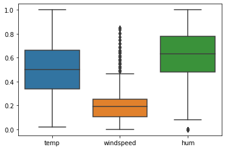

```python
fig,ax = plt.subplots(ncols=1)
sns.boxplot(data=hour_data[['temp', 'windspeed', 'hum']],ax=ax)
```

As seen in the Boxplot, the **windspeed** has outliers which begin from around 0.5 upwards. To lessen the impact of these outliers on the **windspeed** feature, we will use the clip function to trim values above a suitable threshold. In this case, above 0.6. All values above this threshold will be set to 0.6.

As seen in the Boxplot, the **hum** has outliers which are from below around 0.1 and lower. To lessen the impact of these outliers on the **hum** feature, we will use the clip function to trim values below a suitable threshold. In this case, below 0.05. All values above this threshold will be set to 0.05.

```python
hour_data["windspeed"] = hour_data["windspeed"].clip(upper=0.6)
hour_data["hum"] = hour_data["hum"].clip(lower=0.05)
```

Create the boxplot again to see that the outliers have been suitably clipped.

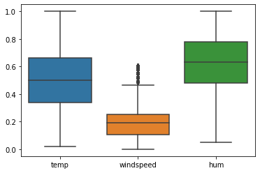

```python
fig,ax = plt.subplots(ncols=1)
sns.boxplot(data=hour_data[['temp', 'windspeed', 'hum']],ax=ax)
```

## Skewness of the variables

Lets now look at the skewness of the target variable, and of the numeric variables:

- cnt
- temp
- windspeed
- hum

Lets plot some histograms and look at the distributions.

Firstly, the target variable, cnt.

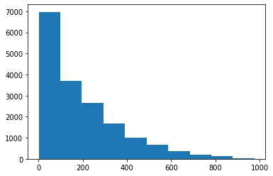

```python
plt.hist(hour_data['cnt'])
```

From the plot above, the target variable's data appears to be right skewed. Therefore, we will replace the value of hour_data['cnt'] with its square root in order to flatten it.

```python
hour_data['cnt'] = np.sqrt(hour_data['cnt'])
```

Plot the histogram again, to see if the skewdness has been flattened:

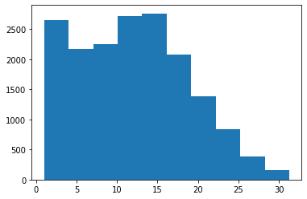

```python
plt.hist(hour_data['cnt'])
```

It has flattened.

Next, the features temp and windspeed.

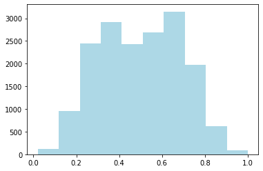

```python
plt.hist(hour_data['temp'], color='lightblue');
```

The temp distribution does not look skewed. Therefore, we do not need to flatten it.

Next, windspeed:

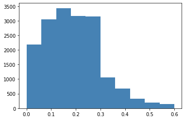

```python
plt.hist(hour_data['windspeed'], color='steelblue');
```

From the plot above, the windspeed variable's data appears to be right skewed. Therefore, we will replace the value of hour_data['windspeed'] with its square root in order to flatten it.

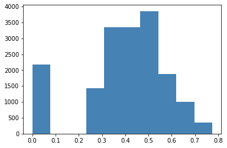

```python
hour_data['windspeed4'] = np.sqrt(hour_data['windspeed'])
plt.hist(hour_data['windspeed4'], color='steelblue')
```

```python
hour_data.head()
```

| dteday | yr | mnth | hr | temp | hum | windspeed | cnt | season_1 | season_2 | season_3 | ... | hr_time_15 | hr_time_16 | hr_time_17 | hr_time_18 | hr_time_19 | hr_time_20 | hr_time_21 | hr_time_22 | hr_time_23 | windspeed4 |
| --- | --- | --- | --- | --- | --- | --- | --- | --- | --- | --- | --- | --- | --- | --- | --- | --- | --- | --- | --- | --- | --- |
| 2011-01-01 00:00:00 | 0 | 1 | 0 | 0.24 | 0.81 | 0.0 | 4.000000 | 1 | 0 | 0 | ... | 0 | 0 | 0 | 0 | 0 | 0 | 0 | 0 | 0 | 0.0 |
| 2011-01-01 01:00:00 | 0 | 1 | 1 | 0.22 | 0.80 | 0.0 | 6.324555 | 1 | 0 | 0 | ... | 0 | 0 | 0 | 0 | 0 | 0 | 0 | 0 | 0 | 0.0 |
| 2011-01-01 02:00:00 | 0 | 1 | 2 | 0.22 | 0.80 | 0.0 | 5.656854 | 1 | 0 | 0 | ... | 0 | 0 | 0 | 0 | 0 | 0 | 0 | 0 | 0 | 0.0 |
| 2011-01-01 03:00:00 | 0 | 1 | 3 | 0.24 | 0.75 | 0.0 | 3.605551 | 1 | 0 | 0 | ... | 0 | 0 | 0 | 0 | 0 | 0 | 0 | 0 | 0 | 0.0 |
| 2011-01-01 04:00:00 | 0 | 1 | 4 | 0.24 | 0.75 | 0.0 | 1.000000 | 1 | 0 | 0 | ... | 0 | 0 | 0 | 0 | 0 | 0 | 0 | 0 | 0 | 0.0 |

5 rows × 51 columns

## Explanatory Analysis

```
[Text(0.5, 1.0, 'Season wise hourly distribution of counts')]
```

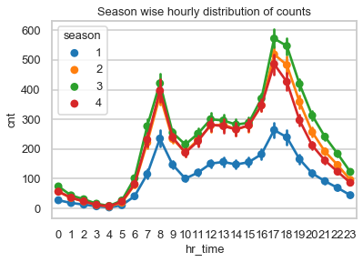

```python
hour_EDA['hr_time'] = hour_EDA.hr.astype('category')
sns.set_style('whitegrid')
sns.set_context('talk', font_scale=0.5, rc={"lines.linewidth": 1.5})
params = {'legend.fontsize': 'x-large', 'axes.labelsize': 'x-large','axes.titlesize':'x-large','xtick.labelsize':'x-large',
          'ytick.labelsize':'x-large',}
plt.rcParams.update(params)
fig,ax = plt.subplots()
sns.pointplot(data=hour_EDA[['hr_time',
                           'cnt',
                           'season']], x='hr_time', y='cnt', hue='season', ax=ax)
ax.set(title="Season wise hourly distribution of counts")
```

```
[Text(0.5, 1.0, 'Seasonal distribution of counts')]
```

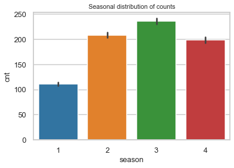

```python
# Seasonal distribution of count
fig,ax = plt.subplots()
sns.barplot(data=hour_EDA[['season', 'cnt']],
              x='season', y='cnt', ax=ax)
sns.set_context('talk', font_scale=0.6, rc={"lines.linewidth": 1.5})
ax.set(title="Seasonal distribution of counts")
```

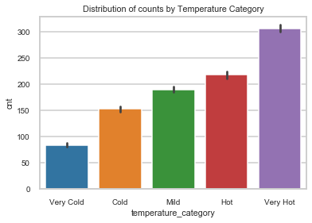

```python
# binning into 5 different temperature bins for ploting

bin_labels_temp = ['Very Cold', 'Cold', 'Mild', 'Hot', 'Very Hot']
hour_EDA['temperature_category'] = pd.qcut(hour_EDA['temp'],  q=[0, .2, .4, .6, .8, 1], labels = bin_labels_temp)
hour_EDA.head()
fig,ax = plt.subplots()
sns.barplot(data=hour_EDA[['temperature_category', 'cnt']], x = 'temperature_category', y = 'cnt', ax = ax)
ax.set(title="Distribution of counts by Temperature Category")
hour_EDA = hour_EDA.drop(["temperature_category"], axis=1)
```

```
[Text(0.5, 1.0, 'Distribution of counts by weathersit')]
```

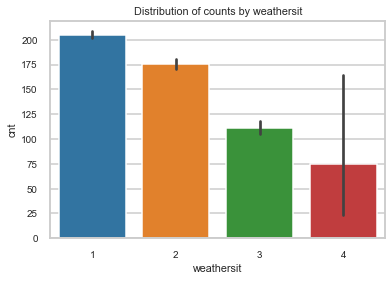

```python
# Ploting distribution of counts by wheathersit
fig,ax = plt.subplots()
sns.barplot(data=hour_EDA[['weathersit',
                           'cnt']],
              x='weathersit',
              y='cnt',
              ax=ax)
sns.set_context('talk', font_scale=0.6, rc={"lines.linewidth": 1.5})
ax.set(title="Distribution of counts by weathersit")
```

```python
%matplotlib inline
import seaborn; seaborn.set()
import matplotlib.pyplot as plt
import matplotlib.dates as mdates
```

#### Weekly Count

Let's now gain more insight by resampling the data by week:

```python
simple_hour_EDA = hour_EDA[["cnt", "registered"]] #only take these columns into the graph
```

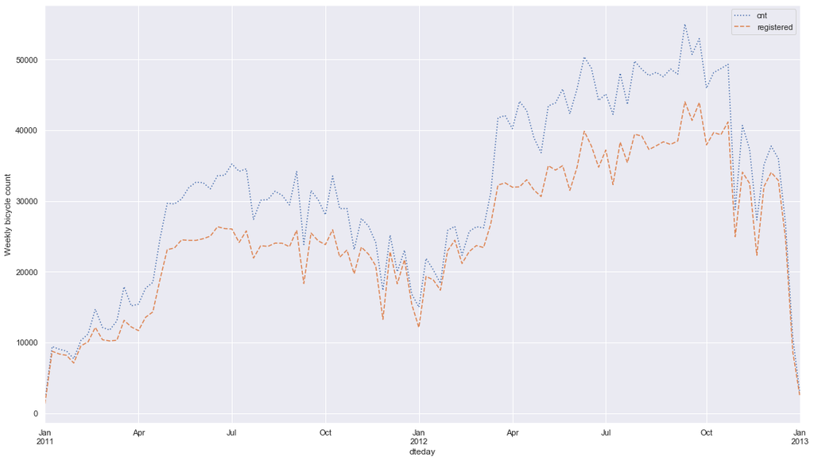

```python
weekly = simple_hour_EDA.resample('W').sum()
weekly.plot(style=[':', '--', '-'])
plt.ylabel('Weekly bicycle count');
fig = plt.gcf()
fig.set_size_inches(18.5, 10.5)
```

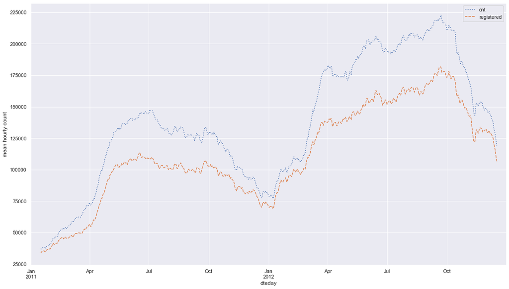

```python
daily = simple_hour_EDA.resample('D').sum()
daily.rolling(30, center=True).sum().plot(style=[':', '--', '-'])
plt.ylabel('mean hourly count');
fig = plt.gcf()
fig.set_size_inches(18.5, 10.5)
```

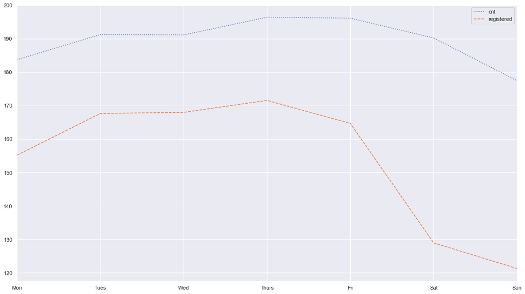

```python
by_weekday = simple_hour_EDA.groupby(hour_EDA.index.dayofweek).mean()
by_weekday.index = ['Mon', 'Tues', 'Wed', 'Thurs', 'Fri', 'Sat', 'Sun']
by_weekday.plot(style=[':', '--', '-']);
# note Jan 1st 2011, Saturday is a 6, Sunday is a 0.
# e.g. 189 is the average of all Saturdays in the dataset
fig = plt.gcf()
fig.set_size_inches(18.5, 10.5)
```

```python
weekend_info_hour_EDA = hour_EDA[["cnt", "registered", "weekday"]] #only take these columns into the graph
#simple_hour_data = hour_data[["cnt", "casual", "registered"]] #only take these columns into the graph
weekend = np.where(weekend_info_hour_EDA.index.weekday < 5, 'Weekday', 'Weekend') #todo re-include the weekday into the plot
by_time = weekend_info_hour_EDA.groupby([weekend, weekend_info_hour_EDA.index.time]).mean()
```

Plot two panels side by side, for the Weekdays and Weekends

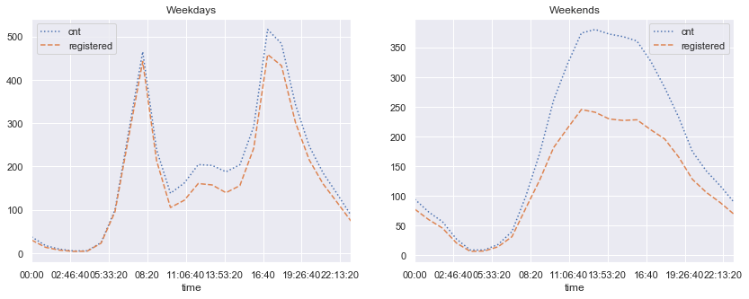

```python
#Todo: use same scale for both
import matplotlib.pyplot as plt

fig, ax = plt.subplots(1, 2, figsize=(14, 5))

by_time.loc['Weekday'].plot(ax=ax[0], title='Weekdays',
                            style=[':', '--', '-'])
by_time.loc['Weekend'].plot(ax=ax[1], title='Weekends',
                            style=[':', '--', '-']);
```

## Feature Engineering

Lets use Binning to create some new features for use in the model

Our first feature is "time of day" which is day bin by specific ranges of time

```python
# Creating time of day
hour_data["time_of_day"] = 0
```

```python
# Binning time of day:
hour_data["time_of_day"][(hour_data["hr"] > 6) & (hour_data["hr"] < 13)] = 1
hour_data["time_of_day"][(hour_data["hr"] > 12) & (hour_data["hr"] < 19)] = 2
hour_data["time_of_day"][(hour_data["hr"] > 18) & (hour_data["hr"] < 22)] = 3
hour_data["time_of_day"][(hour_data["hr"] > 21) & (hour_data["hr"] < 24)] = 4
hour_data["time_of_day"].head()
```

```
dteday
2011-01-01 00:00:00    0
2011-01-01 01:00:00    0
2011-01-01 02:00:00    0
2011-01-01 03:00:00    0
2011-01-01 04:00:00    0
Name: time_of_day, dtype: int64
```

```python
hour_data['hr'] = hour_data.hr.astype('category')
hour_data["time_of_day"].head()
hour_data = hour_data.drop(["hr"], axis=1)
```

Since temp is an important feature, lets create 5 bins for the temperature ranges. We will use the same ones used in the plot above.

```python
# binning into 5 different temperature bins

# They will be in order from 0 - 4, 0 being the coldest
hour_data['temperature_bin'] = pd.qcut(hour_data['temp'],  q=[0, .2, .4, .6, .8, 1],
                                    labels=False, precision=0)
```

Next, binning for humidity.

```python
# binning into 5 different humidity bins

# They will be in order from 0 - 4, 0 being the coldest
hour_data['humidity_bin'] = pd.qcut(hour_data['hum'],  q=[0, .2, .4, .6, .8, 1],
                                    labels=False, precision=0)
```

Checking correlation with new features

```python
correlation_matrix  = hour_data.corr() #correlations
correlation_matrix.style.background_gradient(cmap='coolwarm').set_precision(2)
```

|  | temp | hum | windspeed | cnt | season_1 | season_2 | season_3 | season_4 | holiday_0 | holiday_1 | weekday_0 | weekday_1 | weekday_2 | weekday_3 | weekday_4 | weekday_5 | weekday_6 | workingday_0 | workingday_1 | weathersit_1 | weathersit_2 | weathersit_3 | weathersit_4 | hr_time_0 | hr_time_1 | hr_time_2 | hr_time_3 | hr_time_4 | hr_time_5 | … |
| --- | --- | --- | --- | --- | --- | --- | --- | --- | --- | --- | --- | --- | --- | --- | --- | --- | --- | --- | --- | --- | --- | --- | --- | --- | --- | --- | --- | --- | --- | --- |
| temp | 1 | -0.07 | -0.023 | 0.42 | -0.58 | 0.14 | 0.64 | -0.22 | 0.027 | -0.027 | -0.028 | -0.0041 | 0.024 | 0.021 | 0.021 | -0.0012 | -0.032 | -0.055 | 0.055 | 0.1 | -0.07 | -0.062 | -0.021 | -0.032 | -0.041 | -0.046 | -0.047 | -0.053 | -0.066 | … |
| hum | -0.07 | 1 | -0.29 | -0.35 | -0.13 | -0.00082 | 0.018 | 0.12 | 0.011 | -0.011 | 0.0015 | 0.018 | 0.026 | 0.037 | -0.036 | -0.029 | -0.018 | -0.016 | 0.016 | -0.38 | 0.22 | 0.31 | 0.017 | 0.069 | 0.083 | 0.096 | 0.11 | 0.12 | 0.12 | … |
| windspeed | -0.023 | -0.29 | 1 | 0.11 | 0.12 | 0.065 | -0.09 | -0.089 | -0.0043 | 0.0043 | -0.0072 | -0.0041 | 0.0062 | -0.0093 | 0.0066 | -0.013 | 0.02 | 0.011 | -0.011 | 0.0054 | -0.049 | 0.069 | 0.0015 | -0.048 | -0.054 | -0.061 | -0.066 | -0.058 | -0.068 | … |
| cnt | 0.42 | -0.35 | 0.11 | 1 | -0.25 | 0.059 | 0.15 | 0.034 | 0.031 | -0.031 | -0.021 | -0.015 | -0.0019 | -0.0039 | 0.014 | 0.023 | 0.0042 | -0.024 | 0.024 | 0.11 | -0.036 | -0.14 | -0.0081 | -0.16 | -0.21 | -0.24 | -0.27 | -0.29 | -0.24 | … |
| season_1 | -0.58 | -0.13 | 0.12 | -0.25 | 1 | -0.33 | -0.34 | -0.32 | -0.034 | 0.034 | 0.01 | 0.0026 | -0.011 | -0.0085 | -0.0096 | 0.003 | 0.013 | 0.029 | -0.029 | -0.034 | 0.029 | 0.011 | 0.023 | 0.00053 | 0.00086 | -0.0031 | -0.0096 | -0.011 | -0.0027 | … |
| season_2 | 0.14 | -0.00082 | 0.065 | 0.059 | -0.33 | 1 | -0.34 | -0.33 | 0.024 | -0.024 | -0.0044 | 0.0057 | 0.00064 | 0.0068 | -0.0011 | -0.0026 | -0.005 | -0.016 | 0.016 | -0.01 | -0.0026 | 0.022 | -0.0077 | -0.00012 | 0.00021 | 0.0017 | 0.0035 | 0.0021 | 0.00073 | … |
| season_3 | 0.64 | 0.018 | -0.09 | 0.15 | -0.34 | -0.34 | 1 | -0.34 | 0.026 | -0.026 | -0.011 | -0.0069 | 0.0047 | 0.0029 | 0.012 | 0.0017 | -0.0029 | -0.02 | 0.02 | 0.091 | -0.068 | -0.047 | -0.0078 | -0.00054 | -0.00086 | 0.00068 | 0.0038 | 0.0045 | 0.001 | … |
| season_4 | -0.22 | 0.12 | -0.089 | 0.034 | -0.32 | -0.33 | -0.34 | 1 | -0.018 | 0.018 | 0.0056 | -0.0014 | 0.0053 | -0.0014 | -0.0014 | -0.0021 | -0.0045 | 0.0073 | -0.0073 | -0.048 | 0.043 | 0.014 | -0.0075 | 0.00014 | -0.0002 | 0.0006 | 0.0022 | 0.0043 | 0.00094 | … |
| holiday_0 | 0.027 | 0.011 | -0.0043 | 0.031 | -0.034 | 0.024 | 0.026 | -0.018 | 1 | -1 | 0.071 | -0.28 | 0.047 | 0.046 | 0.023 | 0.023 | 0.071 | -0.25 | 0.25 | -0.0092 | -0.0049 | 0.024 | 0.0023 | -0.00019 | -0.00029 | -0.00074 | 0.0036 | 9.3e-05 | -0.00064 | … |
| holiday_1 | -0.027 | -0.011 | 0.0043 | -0.031 | 0.034 | -0.024 | -0.026 | 0.018 | -1 | 1 | -0.071 | 0.28 | -0.047 | -0.046 | -0.023 | -0.023 | -0.071 | 0.25 | -0.25 | 0.0092 | 0.0049 | -0.024 | -0.0023 | 0.00019 | 0.00029 | 0.00074 | -0.0036 | -9.3e-05 | 0.00064 | … |
| weekday_0 | -0.028 | 0.0015 | -0.0072 | -0.021 | 0.01 | -0.0044 | -0.011 | 0.0056 | 0.071 | -0.071 | 1 | -0.17 | -0.17 | -0.17 | -0.17 | -0.17 | -0.17 | 0.6 | -0.6 | 0.042 | -0.032 | -0.021 | -0.0054 | -0.00043 | -0.00019 | -0.00077 | 0.0031 | 0.0014 | -0.0043 | … |
| weekday_1 | -0.0041 | 0.018 | -0.0041 | -0.015 | 0.0026 | 0.0057 | -0.0069 | -0.0014 | -0.28 | 0.28 | -0.17 | 1 | -0.17 | -0.17 | -0.17 | -0.17 | -0.17 | -0.15 | 0.15 | -0.016 | 0.029 | -0.019 | 0.0072 | 0.0012 | 0.0006 | -0.0025 | -0.002 | -0.0012 | 0.0014 | … |
| weekday_2 | 0.024 | 0.026 | 0.0062 | -0.0019 | -0.011 | 0.00064 | 0.0047 | 0.0053 | 0.047 | -0.047 | -0.17 | -0.17 | 1 | -0.17 | -0.17 | -0.17 | -0.17 | -0.27 | 0.27 | -0.031 | 0.02 | 0.022 | -0.0053 | -0.0012 | -0.0018 | 6.6e-05 | -0.0054 | 0.00052 | -0.00017 | … |
| weekday_3 | 0.021 | 0.037 | -0.0093 | -0.0039 | -0.0085 | 0.0068 | 0.0029 | -0.0014 | 0.046 | -0.046 | -0.17 | -0.17 | -0.17 | 1 | -0.17 | -0.17 | -0.17 | -0.27 | 0.27 | -0.02 | -0.013 | 0.055 | 0.0072 | 0.0005 | 0.00074 | 0.00014 | -0.00022 | -0.0027 | 0.0016 | … |
| weekday_4 | 0.021 | -0.036 | 0.0066 | 0.014 | -0.0096 | -0.0011 | 0.012 | -0.0014 | 0.023 | -0.023 | -0.17 | -0.17 | -0.17 | -0.17 | 1 | -0.17 | -0.17 | -0.26 | 0.26 | 0.012 | -0.0038 | -0.014 | -0.0053 | -0.00019 | 4.9e-05 | 0.00028 | -0.00093 | 0.00075 | 0.00087 | … |
| weekday_5 | -0.0012 | -0.029 | -0.013 | 0.023 | 0.003 | -0.0026 | 0.0017 | -0.0021 | 0.023 | -0.023 | -0.17 | -0.17 | -0.17 | -0.17 | -0.17 | 1 | -0.17 | -0.26 | 0.26 | 0.0041 | 0.0033 | -0.012 | -0.0054 | 8.8e-05 | 0.00032 | 0.0014 | 0.0019 | -0.0023 | 0.0012 | … |
| weekday_6 | -0.032 | -0.018 | 0.02 | 0.0042 | 0.013 | -0.005 | -0.0029 | -0.0045 | 0.071 | -0.071 | -0.17 | -0.17 | -0.17 | -0.17 | -0.17 | -0.17 | 1 | 0.6 | -0.6 | 0.0087 | -0.0033 | -0.01 | 0.0071 | 5.1e-05 | 0.00029 | 0.0014 | 0.0035 | 0.0035 | -0.00052 | … |
| workingday_0 | -0.055 | -0.016 | 0.011 | -0.024 | 0.029 | -0.016 | -0.02 | 0.0073 | -0.25 | 0.25 | 0.6 | -0.15 | -0.27 | -0.27 | -0.26 | -0.26 | 0.6 | 1 | -1 | 0.042 | -0.025 | -0.032 | 0.00045 | -0.00021 | 0.00018 | 0.00071 | 0.0037 | 0.0037 | -0.0034 | … |
| workingday_1 | 0.055 | 0.016 | -0.011 | 0.024 | -0.029 | 0.016 | 0.02 | -0.0073 | 0.25 | -0.25 | -0.6 | 0.15 | 0.27 | 0.27 | 0.26 | 0.26 | -0.6 | -1 | 1 | -0.042 | 0.025 | 0.032 | -0.00045 | 0.00021 | -0.00018 | -0.00071 | -0.0037 | -0.0037 | 0.0034 | … |
| weathersit_1 | 0.1 | -0.38 | 0.0054 | 0.11 | -0.034 | -0.01 | 0.091 | -0.048 | -0.0092 | 0.0092 | 0.042 | -0.016 | -0.031 | -0.02 | 0.012 | 0.0041 | 0.0087 | 0.042 | -0.042 | 1 | -0.82 | -0.41 | -0.018 | 0.0074 | 0.0088 | 0.0052 | -0.0017 | -0.00045 | -0.0048 | … |
| weathersit_2 | -0.07 | 0.22 | -0.049 | -0.036 | 0.029 | -0.0026 | -0.068 | 0.043 | -0.0049 | 0.0049 | -0.032 | 0.029 | 0.02 | -0.013 | -0.0038 | 0.0033 | -0.0033 | -0.025 | 0.025 | -0.82 | 1 | -0.18 | -0.0078 | -0.0032 | -0.0068 | -0.0039 | 0.0038 | 0.00051 | 0.012 | … |
| weathersit_3 | -0.062 | 0.31 | 0.069 | -0.14 | 0.011 | 0.022 | -0.047 | 0.014 | 0.024 | -0.024 | -0.021 | -0.019 | 0.022 | 0.055 | -0.014 | -0.012 | -0.01 | -0.032 | 0.032 | -0.41 | -0.18 | 1 | -0.0039 | -0.0076 | -0.0054 | -0.0025 | -0.0031 | 9.6e-05 | -0.01 | … |
| weathersit_4 | -0.021 | 0.017 | 0.0015 | -0.0081 | 0.023 | -0.0077 | -0.0078 | -0.0075 | 0.0023 | -0.0023 | -0.0054 | 0.0072 | -0.0053 | 0.0072 | -0.0053 | -0.0054 | 0.0071 | 0.00045 | -0.00045 | -0.018 | -0.0078 | -0.0039 | 1 | -0.0027 | 0.019 | -0.0027 | -0.0027 | -0.0027 | -0.0027 | … |
| hr_time_0 | -0.032 | 0.069 | -0.048 | -0.16 | 0.00053 | -0.00012 | -0.00054 | 0.00014 | -0.00019 | 0.00019 | -0.00043 | 0.0012 | -0.0012 | 0.0005 | -0.00019 | 8.8e-05 | 5.1e-05 | -0.00021 | 0.00021 | 0.0074 | -0.0032 | -0.0076 | -0.0027 | 1 | -0.044 | -0.043 | -0.043 | -0.043 | -0.043 | … |
| hr_time_1 | -0.041 | 0.083 | -0.054 | -0.21 | 0.00086 | 0.00021 | -0.00086 | -0.0002 | -0.00029 | 0.00029 | -0.00019 | 0.0006 | -0.0018 | 0.00074 | 4.9e-05 | 0.00032 | 0.00029 | 0.00018 | -0.00018 | 0.0088 | -0.0068 | -0.0054 | 0.019 | -0.044 | 1 | -0.043 | -0.043 | -0.043 | -0.043 | … |
| hr_time_2 | -0.046 | 0.096 | -0.061 | -0.24 | -0.0031 | 0.0017 | 0.00068 | 0.0006 | -0.00074 | 0.00074 | -0.00077 | -0.0025 | 6.6e-05 | 0.00014 | 0.00028 | 0.0014 | 0.0014 | 0.00071 | -0.00071 | 0.0052 | -0.0039 | -0.0025 | -0.0027 | -0.043 | -0.043 | 1 | -0.042 | -0.042 | -0.043 | … |
| hr_time_3 | -0.047 | 0.11 | -0.066 | -0.27 | -0.0096 | 0.0035 | 0.0038 | 0.0022 | 0.0036 | -0.0036 | 0.0031 | -0.002 | -0.0054 | -0.00022 | -0.00093 | 0.0019 | 0.0035 | 0.0037 | -0.0037 | -0.0017 | 0.0038 | -0.0031 | -0.0027 | -0.043 | -0.043 | -0.042 | 1 | -0.042 | -0.042 | … |
| hr_time_4 | -0.053 | 0.12 | -0.058 | -0.29 | -0.011 | 0.0021 | 0.0045 | 0.0043 | 9.3e-05 | -9.3e-05 | 0.0014 | -0.0012 | 0.00052 | -0.0027 | 0.00075 | -0.0023 | 0.0035 | 0.0037 | -0.0037 | -0.00045 | 0.00051 | 9.6e-05 | -0.0027 | -0.043 | -0.043 | -0.042 | -0.042 | 1 | -0.042 | … |
| hr_time_5 | -0.066 | 0.12 | -0.068 | -0.24 | -0.0027 | 0.00073 | 0.001 | 0.00094 | -0.00064 | 0.00064 | -0.0043 | 0.0014 | -0.00017 | 0.0016 | 0.00087 | 0.0012 | -0.00052 | -0.0034 | 0.0034 | -0.0048 | 0.012 | -0.01 | -0.0027 | -0.043 | -0.043 | -0.043 | -0.042 | -0.042 | 1 | … |
| hr_time_6 | -0.07 | 0.13 | -0.055 | -0.13 | 0.00069 | 4.6e-05 | -0.00037 | -0.00037 | -0.00024 | 0.00024 | -0.0011 | 0.00048 | -0.00027 | 0.00062 | -6.8e-05 | 0.00021 | 0.00017 | -0.00064 | 0.00064 | -0.014 | 0.018 | -0.0044 | -0.0027 | -0.044 | -0.044 | -0.043 | -0.043 | -0.043 | -0.043 | … |
| hr_time_7 | -0.063 | 0.11 | -0.045 | 0.037 | 0.001 | -0.00029 | -5.1e-05 | -0.00069 | -0.00014 | 0.00014 | 0.00028 | 0.00025 | -0.00051 | 0.00038 | -0.0003 | -3e-05 | -6.7e-05 | 0.00021 | -0.00021 | -0.021 | 0.016 | 0.011 | -0.0027 | -0.044 | -0.044 | -0.043 | -0.043 | -0.043 | -0.043 | … |
| hr_time_8 | -0.046 | 0.082 | -0.023 | 0.18 | 0.001 | -0.00029 | -5.1e-05 | -0.00069 | -0.00014 | 0.00014 | 0.00028 | 0.00025 | -0.00051 | 0.00038 | -0.0003 | -3e-05 | -6.7e-05 | 0.00021 | -0.00021 | -0.023 | 0.025 | -0.0014 | -0.0027 | -0.044 | -0.044 | -0.043 | -0.043 | -0.043 | -0.043 | … |
| hr_time_9 | -0.022 | 0.037 | 0.0022 | 0.074 | 0.001 | -0.00029 | -5.1e-05 | -0.00069 | -0.00014 | 0.00014 | 0.00028 | 0.00025 | -0.00051 | 0.00038 | -0.0003 | -3e-05 | -6.7e-05 | 0.00021 | -0.00021 | -0.029 | 0.035 | -0.0056 | -0.0027 | -0.044 | -0.044 | -0.043 | -0.043 | -0.043 | -0.043 | … |
| hr_time_10 | 0.0039 | -0.012 | 0.021 | 0.019 | 0.001 | -0.00029 | -5.1e-05 | -0.00069 | -0.00014 | 0.00014 | 0.00028 | 0.00025 | -0.00051 | 0.00038 | -0.0003 | -3e-05 | -6.7e-05 | 0.00021 | -0.00021 | -0.02 | 0.026 | -0.0067 | -0.0027 | -0.044 | -0.044 | -0.043 | -0.043 | -0.043 | -0.043 | … |
| hr_time_11 | 0.028 | -0.06 | 0.03 | 0.055 | 0.001 | -0.00029 | -5.1e-05 | -0.00069 | -0.00014 | 0.00014 | 0.00028 | 0.00025 | -0.00051 | 0.00038 | -0.0003 | -3e-05 | -6.7e-05 | 0.00021 | -0.00021 | -0.018 | 0.028 | -0.013 | -0.0027 | -0.044 | -0.044 | -0.043 | -0.043 | -0.043 | -0.043 | … |
| hr_time_12 | 0.047 | -0.098 | 0.044 | 0.1 | 0.0015 | -0.00046 | -0.00022 | -0.00085 | -9.5e-05 | 9.5e-05 | 0.00016 | 0.00013 | 0.0002 | 0.00027 | -0.00042 | -0.00015 | -0.00019 | 1.3e-05 | -1.3e-05 | -0.021 | 0.026 | -0.0047 | -0.0027 | -0.044 | -0.044 | -0.043 | -0.043 | -0.043 | -0.043 | … |
| hr_time_13 | 0.063 | -0.13 | 0.054 | 0.1 | 0.0014 | -0.00062 | -0.00039 | -0.00035 | -4.5e-05 | 4.5e-05 | 3.9e-05 | 1.1e-05 | 0.00091 | 0.00015 | -0.00054 | -0.00026 | -0.0003 | -0.00018 | 0.00018 | -0.0095 | 0.011 | -0.0016 | -0.0027 | -0.044 | -0.044 | -0.043 | -0.043 | -0.043 | -0.043 | … |
| hr_time_14 | 0.074 | -0.14 | 0.073 | 0.087 | 0.0014 | -0.00062 | -0.00039 | -0.00035 | -4.5e-05 | 4.5e-05 | 3.9e-05 | 1.1e-05 | 0.00091 | 0.00015 | -0.00054 | -0.00026 | -0.0003 | -0.00018 | 0.00018 | -0.0029 | 0.0022 | 0.0015 | -0.0027 | -0.044 | -0.044 | -0.043 | -0.043 | -0.043 | -0.043 | … |
| hr_time_15 | 0.078 | -0.15 | 0.077 | 0.099 | 0.0014 | -0.00062 | -0.00039 | -0.00035 | -4.5e-05 | 4.5e-05 | 3.9e-05 | 1.1e-05 | 0.00091 | 0.00015 | -0.00054 | -0.00026 | -0.0003 | -0.00018 | 0.00018 | 0.0038 | -0.0082 | 0.0068 | -0.0027 | -0.044 | -0.044 | -0.043 | -0.043 | -0.043 | -0.043 | … |
| hr_time_16 | 0.074 | -0.14 | 0.081 | 0.16 | 0.0019 | -0.00079 | -0.00056 | -0.00051 | 4e-06 | -4e-06 | -7.8e-05 | -0.00011 | 0.00079 | 3.1e-05 | 0.00017 | -0.00038 | -0.00042 | -0.00038 | 0.00038 | 0.018 | -0.027 | 0.0098 | 0.019 | -0.044 | -0.044 | -0.043 | -0.043 | -0.043 | -0.043 | … |
| hr_time_17 | 0.063 | -0.12 | 0.073 | 0.27 | 0.0019 | -0.00079 | -0.00056 | -0.00051 | 4e-06 | -4e-06 | -7.8e-05 | -0.00011 | 0.00079 | 3.1e-05 | 0.00017 | -0.00038 | -0.00042 | -0.00038 | 0.00038 | 0.017 | -0.029 | 0.017 | -0.0028 | -0.044 | -0.044 | -0.043 | -0.043 | -0.043 | -0.043 | … |
| hr_time_18 | 0.048 | -0.099 | 0.059 | 0.24 | 0.0015 | -0.00046 | -0.00088 | -0.00019 | -9.5e-05 | 9.5e-05 | 0.00016 | 0.00013 | 0.001 | -0.00056 | 0.0004 | -0.00015 | -0.001 | -0.0006 | 0.0006 | 0.013 | -0.021 | 0.01 | 0.019 | -0.044 | -0.044 | -0.043 | -0.043 | -0.043 | -0.043 | … |
| hr_time_19 | 0.03 | -0.059 | 0.035 | 0.15 | 0.0015 | -0.00046 | -0.00088 | -0.00019 | -9.5e-05 | 9.5e-05 | 0.00016 | 0.00013 | 0.001 | -0.00056 | 0.0004 | -0.00015 | -0.001 | -0.0006 | 0.0006 | 0.019 | -0.02 | -0.00046 | -0.0027 | -0.044 | -0.044 | -0.043 | -0.043 | -0.043 | -0.043 | … |
| hr_time_20 | 0.013 | -0.028 | 0.0089 | 0.075 | 0.0015 | -0.00046 | -0.00088 | -0.00019 | -9.5e-05 | 9.5e-05 | 0.00016 | 0.00013 | 0.001 | -0.00056 | 0.0004 | -0.00015 | -0.001 | -0.0006 | 0.0006 | 0.025 | -0.033 | 0.009 | -0.0027 | -0.044 | -0.044 | -0.043 | -0.043 | -0.043 | -0.043 | … |
| hr_time_21 | -0.0018 | 0.0047 | -0.016 | 0.018 | 0.0015 | -0.00046 | -0.00088 | -0.00019 | -9.5e-05 | 9.5e-05 | 0.00016 | 0.00013 | 0.001 | -0.00056 | 0.0004 | -0.00015 | -0.001 | -0.0006 | 0.0006 | 0.021 | -0.021 | -0.0026 | -0.0027 | -0.044 | -0.044 | -0.043 | -0.043 | -0.043 | -0.043 | … |
| hr_time_22 | -0.014 | 0.028 | -0.026 | -0.032 | 0.0015 | -0.00046 | -0.00088 | -0.00019 | -9.5e-05 | 9.5e-05 | 0.00016 | 0.00013 | 0.001 | -0.00056 | 0.0004 | -0.00015 | -0.001 | -0.0006 | 0.0006 | 0.019 | -0.017 | -0.0047 | -0.0027 | -0.044 | -0.044 | -0.043 | -0.043 | -0.043 | -0.043 | … |
| hr_time_23 | -0.024 | 0.05 | -0.043 | -0.095 | 0.0015 | -0.00046 | -0.00088 | -0.00019 | -9.5e-05 | 9.5e-05 | 0.00016 | 0.00013 | 0.001 | -0.00056 | 0.0004 | -0.00015 | -0.001 | -0.0006 | 0.0006 | 0.0084 | -0.014 | 0.0079 | -0.0027 | -0.044 | -0.044 | -0.043 | -0.043 | -0.043 | -0.043 | … |
| windspeed4 | -0.0046 | -0.25 | 0.94 | 0.11 | 0.091 | 0.074 | -0.071 | -0.093 | 6.5e-05 | -6.5e-05 | -0.0022 | -0.0052 | 0.0075 | -0.015 | 0.0082 | -0.012 | 0.019 | 0.012 | -0.012 | -0.0059 | -0.033 | 0.064 | 0.003 | -0.043 | -0.05 | -0.06 | -0.062 | -0.051 | -0.06 | … |
| time_of_day | 0.11 | -0.23 | 0.11 | 0.42 | 0.0083 | -0.0028 | -0.0035 | -0.0019 | -0.00046 | 0.00046 | 0.00071 | 0.00055 | 0.0041 | -0.0012 | 0.00051 | -0.00099 | -0.0037 | -0.0021 | 0.0021 | 0.04 | -0.053 | 0.016 | -0.0014 | -0.24 | -0.24 | -0.24 | -0.24 | -0.24 | -0.24 | … |
| temperature_bin | 0.97 | -0.057 | -0.029 | 0.41 | -0.56 | 0.14 | 0.64 | -0.23 | 0.032 | -0.032 | -0.029 | 0.0046 | 0.021 | 0.024 | 0.022 | -0.0071 | -0.035 | -0.06 | 0.06 | 0.1 | -0.071 | -0.062 | -0.019 | -0.028 | -0.036 | -0.043 | -0.043 | -0.054 | -0.062 | … |
| humidity_bin | -0.05 | 0.97 | -0.28 | -0.34 | -0.14 | 0.0063 | 0.035 | 0.099 | 0.01 | -0.01 | -0.0049 | 0.016 | 0.033 | 0.033 | -0.033 | -0.03 | -0.014 | -0.018 | 0.018 | -0.37 | 0.21 | 0.3 | 0.019 | 0.068 | 0.081 | 0.093 | 0.11 | 0.12 | 0.12 | … |

After generating the matrix again, the list of the most important features looks like this:

| Feature Name | Correlation |
| --- | --- |
| Temp | 0.42 |
| time_of_day | 0.42 |
| temp and temperature_bin | 0.41 |
| hum | -0.35 |
| hum and humidity_bin | -0.34 |
| yr | 0.25 |
| windspeed | 0.11 |
| windspeed4 | 0.11 |

# Dimensionality reduction

### PCA as dimensionality reduction

Using PCA for dimensionality reduction involves zeroing out one or more of the smallest principal components, resulting in a lower-dimensional projection of the data that preserves the maximal data variance.

```python
# Split the train set into the independent and target variables
# Convert the variables to 2d numpy arrays (as required by sklearn)
#hour_data.drop('datetime', axis = 1).values #temporaty
XPCA = hour_data.drop('cnt', axis = 1).values
yPCA = hour_data['cnt'].values
hour_data.head()
```

| dteday | yr | mnth | temp | hum | windspeed | cnt | season_1 | season_2 | season_3 | season_4 | ... | hr_time_18 | hr_time_19 | hr_time_20 | hr_time_21 | hr_time_22 | hr_time_23 | windspeed4 | time_of_day | temperature_bin | humidity_bin |
| --- | --- | --- | --- | --- | --- | --- | --- | --- | --- | --- | --- | --- | --- | --- | --- | --- | --- | --- | --- | --- | --- |
| 2011-01-01 00:00:00 | 0 | 1 | 0.24 | 0.81 | 0.0 | 4.000000 | 1 | 0 | 0 | 0 | ... | 0 | 0 | 0 | 0 | 0 | 0 | 0.0 | 0 | 0 | 3 |
| 2011-01-01 01:00:00 | 0 | 1 | 0.22 | 0.80 | 0.0 | 6.324555 | 1 | 0 | 0 | 0 | ... | 0 | 0 | 0 | 0 | 0 | 0 | 0.0 | 0 | 0 | 3 |
| 2011-01-01 02:00:00 | 0 | 1 | 0.22 | 0.80 | 0.0 | 5.656854 | 1 | 0 | 0 | 0 | ... | 0 | 0 | 0 | 0 | 0 | 0 | 0.0 | 0 | 0 | 3 |
| 2011-01-01 03:00:00 | 0 | 1 | 0.24 | 0.75 | 0.0 | 3.605551 | 1 | 0 | 0 | 0 | ... | 0 | 0 | 0 | 0 | 0 | 0 | 0.0 | 0 | 0 | 3 |
| 2011-01-01 04:00:00 | 0 | 1 | 0.24 | 0.75 | 0.0 | 1.000000 | 1 | 0 | 0 | 0 | ... | 0 | 0 | 0 | 0 | 0 | 0 | 0.0 | 0 | 0 | 3 |

5 rows × 53 columns

```python
from sklearn.decomposition import PCA
pca = PCA(n_components=20)
pca.fit(XPCA)
X_pca = pca.transform(XPCA)
print("original shape:   ", XPCA.shape)
print("transformed shape:", X_pca.shape)
```

```
original shape:    (17379, 52)
transformed shape: (17379, 20)
```

```python
print(pca.explained_variance_)
```

```
[12.13242805  2.4308046   1.96348542  1.36983694  0.56397621  0.33591149
  0.25230292  0.24708337  0.14947436  0.1442416   0.14306506  0.14236626
  0.14134258  0.10329198  0.10042068  0.06695725  0.05936942  0.042418
  0.04194529  0.04191702]
```

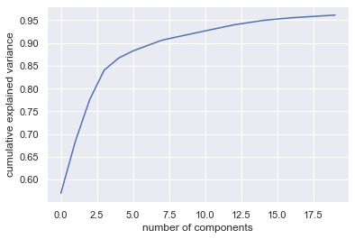

```python
plt.plot(np.cumsum(pca.explained_variance_ratio_))
plt.xlabel('number of components')
plt.ylabel('cumulative explained variance');
plt.show()
```

### Droping new generated features if needed

```python
# We try combinations of features in manny models. In this code is where we automatize
hour_data = hour_data.drop(['temp','hum','windspeed'], axis=1)
```

# Splitting Dataset without using PCA

```python
# Spliting Dataset into test
test_set = hour_data[hour_data.index >= "2012-10-01 00:00:00"]
```

```python
# Spliting Dataset into training
train_set = hour_data[hour_data.index <= "2012-10-01 00:00:00"]
```

# Modeling

1)Simple Linear model - Baseline Model

2)Ridge Linear Regression

3)Lasso Model with cross Validation

4)Decision Tree Model with CV

5)Random Forest Model with CV and Grid Search

6)Random Forest Model with Ramdom Search

7)Simple Linear model - Baseline Model simple

## Simple Linear model - Baseline Model

```python
from sklearn.linear_model import LinearRegression
from sklearn.metrics import r2_score,mean_absolute_error, mean_squared_error
%matplotlib inline
```

```python
# Split the train set into the independent and target variables
# Convert the variables to 2d numpy arrays (as required by sklearn)

train_set = pd.DataFrame(train_set)
X = train_set.drop('cnt', axis = 1).values
y = train_set['cnt'].values
print(X.shape, y.shape)
```

[output not shown]

```python
#Training the Algorithm
regressor = LinearRegression()
regressor.fit(X, y)
```

```
LinearRegression(copy_X=True, fit_intercept=True, n_jobs=None, normalize=False)
```

```python
# Printing regresion coeficients
regressor.coef_
```

```
array([ 3.03501861e+00,  1.15485169e-01, -3.34834336e+00,  2.29245325e+12,
        2.29245325e+12,  2.29245325e+12,  2.29245325e+12,  1.16815284e+12,
        5.72276455e+11, -4.70940147e+11,  1.24936238e+11,  1.24936238e+11,
        1.24936238e+11,  1.24936238e+11,  1.24936238e+11, -4.70940147e+11,
        6.25375678e+11,  2.94992923e+10,  1.95680443e+12,  1.95680443e+12,
        1.95680443e+12,  1.95680443e+12, -9.89470362e+10, -9.89470362e+10,
       -9.89470362e+10, -9.89470362e+10, -9.89470362e+10, -9.89470362e+10,
       -9.89470362e+10, -6.92652366e+10, -6.92652366e+10, -6.92652366e+10,
       -6.92652366e+10, -6.92652366e+10, -6.92652366e+10, -3.95834370e+10,
       -3.95834370e+10, -3.95834370e+10, -3.95834370e+10, -3.95834370e+10,
       -3.95834370e+10, -9.90163742e+09, -9.90163742e+09, -9.90163743e+09,
        1.97801622e+10,  1.97801622e+10,  1.47631836e+00, -2.96817996e+10,
        1.11242676e+00, -3.21289062e-01])
```

```python
#Defininf y predicted for training
y_pred = regressor.predict(X)
# Calculating R2 for training
r2_score(y, y_pred)
```

```
0.7886429518243268
```

## Making Predictions

```python
# Defining test set
X = test_set.drop('cnt', axis = 1).values
y = test_set['cnt'].values
# Predicting Test Set
y_pred = regressor.predict(X)
# Calculating R2
r2_score(y, y_pred)
```

```
0.7373472574593908
```

```python
df = pd.DataFrame({'Actual': y, 'Predicted': y_pred})
```

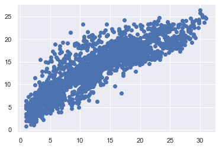

```python
# Simple plot to check the predictions
plt.scatter(y, y_pred)
```

## Evaluating Algorithm

```python
from sklearn import metrics
# Calculating R2
r2 = r2_score(y, y_pred)
print('R square:', r2)
#Calculating other Metrics
print('Mean Absolute Error:', metrics.mean_absolute_error(y, y_pred))
print('Mean Squared Error:', metrics.mean_squared_error(y, y_pred))
print('Root Mean Squared Error:', np.sqrt(metrics.mean_squared_error(y, y_pred)))
```

```
R square: 0.7373472574593908
Mean Absolute Error: 2.8490764181555286
Mean Squared Error: 13.310834996433739
Root Mean Squared Error: 3.648401704367782
```

## Model: Ridge Linear Regression

```python
# Split the train set into the independent and target variables
# Convert the variables to 2d numpy arrays (as required by sklearn)
train_set = pd.DataFrame(train_set)
X = train_set.drop('cnt', axis = 1).values
y = train_set['cnt'].values
#Checking shape
print(X.shape, y.shape)
```

```
(15212, 50) (15212,)
```

```python
#Dowloading Gridsearch
from sklearn.model_selection import  GridSearchCV
```

```python
#Training the Algorithm
from sklearn.linear_model import LinearRegression, Ridge
regressor = Ridge()
params = [{"alpha": [10,20,100,150,]}]
GridSearch = GridSearchCV(regressor, cv= 10, param_grid= params)
GridSearch.fit(X, y)
print(GridSearch.best_params_)
```

```
{'alpha': 20}
```

```python
#Runing model to predict training set
y_pred = GridSearch.best_estimator_.predict(X)
r2_score(y, y_pred) #R2 of trainig set predicted
```

```
0.7880990943894336
```

## Prediction

Predicting the counts for the test data

```python
# Split the test set into the independent and target variables
# Convert the variables to 2d numpy arrays (as required by sklearn)
X = test_set.drop('cnt', axis = 1).values
y = test_set['cnt'].values
```

```python
# Modeling the test set
y_pred = GridSearch.best_estimator_.predict(X)
r2_score(y, y_pred) #R2 for test prediction
```

```
0.7337694944363801
```

The training R2 (0.788)is bigger than the test R2(0.733) indicating that there could by bias on the model

## Lasso Model with cross Validation

```python
from sklearn.linear_model import LassoCV, Lasso
```

```python
# Split the train set into the independent and target variables
# Convert the variables to 2d numpy arrays (as required by sklearn)
X = train_set.drop('cnt', axis = 1).values
y = train_set['cnt'].values
```

```python
# Define alpha space to select the best alphas (we use logspace in order to search for very small numbers close to cero)
alpha_space = np.logspace(-4, 0, 50)
alpha_space
```

```
array([1.00000000e-04, 1.20679264e-04, 1.45634848e-04, 1.75751062e-04,
       2.12095089e-04, 2.55954792e-04, 3.08884360e-04, 3.72759372e-04,
       4.49843267e-04, 5.42867544e-04, 6.55128557e-04, 7.90604321e-04,
       9.54095476e-04, 1.15139540e-03, 1.38949549e-03, 1.67683294e-03,
       2.02358965e-03, 2.44205309e-03, 2.94705170e-03, 3.55648031e-03,
       4.29193426e-03, 5.17947468e-03, 6.25055193e-03, 7.54312006e-03,
       9.10298178e-03, 1.09854114e-02, 1.32571137e-02, 1.59985872e-02,
       1.93069773e-02, 2.32995181e-02, 2.81176870e-02, 3.39322177e-02,
       4.09491506e-02, 4.94171336e-02, 5.96362332e-02, 7.19685673e-02,
       8.68511374e-02, 1.04811313e-01, 1.26485522e-01, 1.52641797e-01,
       1.84206997e-01, 2.22299648e-01, 2.68269580e-01, 3.23745754e-01,
       3.90693994e-01, 4.71486636e-01, 5.68986603e-01, 6.86648845e-01,
       8.28642773e-01, 1.00000000e+00])
```

```python
# Define a cross validated lasso regression optimisation model that takes all the numbers in the alpha space to find one that minimizes mean squared error.
lassocv = LassoCV(cv = 10, alphas = alpha_space, normalize = True,max_iter = 1e5)
```

```python
# Train the lasso CV and find the Alpha that minimises the mean_squared error
lassocv.fit(X, y)
lassocv.alpha_
```

```
0.0001
```

```python
# Define a Lasso function with the alpha found in the lasso CV model
lasso = Lasso(alpha = lassocv.alpha_, normalize=True)
```

```python
# Final model is the Lasso regression with the optimised Alpha
model = lasso.fit(X, y)
```

```python
# Defining test set
X = test_set.drop('cnt', axis = 1).values
y = test_set['cnt'].values
```

```python
# Predict the y for the test set
y_pred = model.predict(X)
```

```python
# Check R2
lasso.score(X, y)
```

```
0.7364521962692473
```

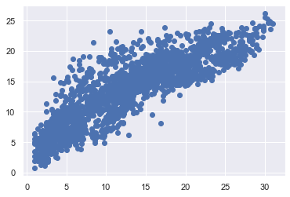

```python
# Simple plot to check the predictions

plt.scatter(y, y_pred)
```

```python
from sklearn import metrics
print('Mean Absolute Error:', metrics.mean_absolute_error(y, y_pred))
print('Mean Squared Error:', metrics.mean_squared_error(y, y_pred))
print('Root Mean Squared Error:', np.sqrt(metrics.mean_squared_error(y, y_pred)))
```

```
Mean Absolute Error: 2.853664390443387
Mean Squared Error: 13.35619531400921
Root Mean Squared Error: 3.6546128815524646
```

## Decision Tree Model with CV

```python
from sklearn.model_selection import GridSearchCV
from pprint import pprint
from sklearn.tree import DecisionTreeRegressor
```

```python
# Split the train set into the independent and target variables
# Convert the variables to 2d numpy arrays (as required by sklearn)
train_set = pd.DataFrame(train_set)
X = train_set.drop('cnt', axis = 1).values
y = train_set['cnt'].values
print(X.shape, y.shape)
```

```
(15212, 50) (15212,)
```

```python
tree = DecisionTreeRegressor()
parameters = {'max_depth':range(1,40)}
clf = GridSearchCV(tree,cv= 10, param_grid = parameters, n_jobs=10)
```

```python
clf.fit(X, y)
```

```
GridSearchCV(cv=10, error_score='raise-deprecating',
             estimator=DecisionTreeRegressor(criterion='mse', max_depth=None,
                                             max_features=None,
                                             max_leaf_nodes=None,
                                             min_impurity_decrease=0.0,
                                             min_impurity_split=None,
                                             min_samples_leaf=1,
                                             min_samples_split=2,
                                             min_weight_fraction_leaf=0.0,
                                             presort=False, random_state=None,
                                             splitter='best'),
             iid='warn', n_jobs=10, param_grid={'max_depth': range(1, 40)},
             pre_dispatch='2*n_jobs', refit=True, return_train_score=False,
             scoring=None, verbose=0)
```

```python
tree_model = clf.best_estimator_
tree_model
```

```
DecisionTreeRegressor(criterion='mse', max_depth=18, max_features=None,
                      max_leaf_nodes=None, min_impurity_decrease=0.0,
                      min_impurity_split=None, min_samples_leaf=1,
                      min_samples_split=2, min_weight_fraction_leaf=0.0,
                      presort=False, random_state=None, splitter='best')
```

```python
# R2 before testing
y_pred = tree_model.predict(X)
r2_score(y, y_pred)
```

```
0.9846064980057727
```

```python
print (clf.best_params_)
```

```
{'max_depth': 18}
```

```python
# Defining test set
X = test_set.drop('cnt', axis = 1).values
y = test_set['cnt'].values
```

```python
y_pred = tree_model.predict(X)
```

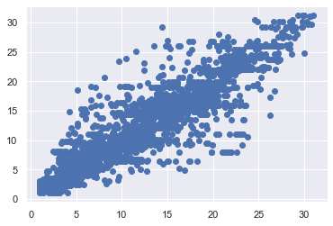

```python
# Simple plot to check the predictions
plt.scatter(y, y_pred)
```

```python
from sklearn import metrics
print('Mean Absolute Error:', metrics.mean_absolute_error(y, y_pred))
print('Mean Squared Error:', metrics.mean_squared_error(y, y_pred))
print('Root Mean Squared Error:', np.sqrt(metrics.mean_squared_error(y, y_pred)))
```

```
Mean Absolute Error: 2.1733555295603173
Mean Squared Error: 10.208152589651345
Root Mean Squared Error: 3.195019967019196
```

```python
r2_score(y, y_pred) # R2 score
```

```
0.7985701667353475
```

# Best Models

## Random Forest Model with CV and Grid Search

```python
# Split the train set into the independent and target variables
# Convert the variables to 2d numpy arrays (as required by sklearn)
train_set = pd.DataFrame(train_set)
X = train_set.drop('cnt', axis = 1).values
y = train_set['cnt'].values
print(X.shape, y.shape)
```

```
(15212, 50) (15212,)
```

```python
# Loading Library
from sklearn.ensemble import RandomForestRegressor

# Defining model with no gridsearch
Forest = RandomForestRegressor(n_estimators=20, random_state=0)
Forest.fit(X, y)

# Defining and tuning with GridSearch model
parameters = {'max_depth':[10, 15], 'min_samples_split':[20,30,35,40], 'min_samples_leaf':[10], 'n_estimators':[20, 21, 22, 23], 'max_leaf_nodes':[85]}
RFR = GridSearchCV(Forest,cv= 10, param_grid = parameters, n_jobs=10)
```

```python
# Running  tunned model in train set
RFR.fit(X, y)

# Best paramater selection and optimization
Forest_model = RFR.best_estimator_
Forest_model
```

```
RandomForestRegressor(bootstrap=True, criterion='mse', max_depth=15,
                      max_features='auto', max_leaf_nodes=85,
                      min_impurity_decrease=0.0, min_impurity_split=None,
                      min_samples_leaf=10, min_samples_split=40,
                      min_weight_fraction_leaf=0.0, n_estimators=21,
                      n_jobs=None, oob_score=False, random_state=0, verbose=0,
                      warm_start=False)
```

```python
# R2 of the No GridSearch model before testing
y_pred = Forest_model.predict(X)
r2_score(y, y_pred)
```

```
0.9024110554781015
```

```python
# Defining test set for model with no gridsearch
X = test_set.drop('cnt', axis = 1).values
y = test_set['cnt'].values

# Predicting Y for model with no gridsearch
y_pred = Forest.predict(X)

# R2
r2_score(y, y_pred)
```

```
0.870630568640802
```

0.870630568640802 is the highest r2 score among all models